# EORTC HNSCC ICI Honore et al_02032025

library(swimplot) library(grid) library(gtable) library(readr) library(mosaic) library(dplyr) library(survival) library(survminer) library(ggplot2) library(scales) library(coxphf) library(ggthemes) library(tidyverse) library(gtsummary) library(flextable) library(parameters) library(car) library(ComplexHeatmap) library(tidyverse) library(readxl) library(janitor) library(DT) library(pROC) library(rms)

#ctDNA Detection Rates by Window and Stages

```r
#ctDNA at Baseline
rm(list=ls())
setwd("~/Downloads")
circ_data <- read.csv("EORTC HNSCC ICI Clinical Data.csv")
circ_data <- circ_data[circ_data$ctDNA.available=="TRUE",]
circ_data <- circ_data[circ_data$ctDNA.Base!="",]
circ_data$ctDNA.Base <- factor(circ_data$ctDNA.Base, levels=c("NEGATIVE","POSITIVE"))
circ_data <- subset(circ_data, ctDNA.Base %in% c("NEGATIVE", "POSITIVE"))
circ_data$Stage <- factor(circ_data$Stage, levels=c("O","I","II","III","IV"))
positive_counts_by_stage <- aggregate(circ_data$ctDNA.Base == "POSITIVE", by=list(circ_data$Stage), FUN=sum)
total_counts_by_stage <- aggregate(circ_data$ctDNA.Base, by=list(circ_data$Stage), FUN=length)
combined_data <- data.frame(
  Stage = total_counts_by_stage$Group.1,
  Total_Count = total_counts_by_stage$x,
  Positive_Count = positive_counts_by_stage$x,
  Rate = (positive_counts_by_stage$x / total_counts_by_stage$x) * 100  # Convert to percentage
)
combined_data$Rate <- sprintf("%.2f%%", combined_data$Rate)
overall_total_count <- nrow(circ_data)
overall_positive_count <- nrow(circ_data[circ_data$ctDNA.Base == "POSITIVE",])
overall_positivity_rate <- (overall_positive_count / overall_total_count) * 100  # Convert to percentage
overall_row <- data.frame(
  Stage = "Overall",
  Total_Count = overall_total_count,
  Positive_Count = overall_positive_count,
  Rate = sprintf("%.2f%%", overall_positivity_rate)
)
combined_data <- rbind(combined_data, overall_row)
print(combined_data)
```

| Stage | Total_Count | Positive_Count | Rate |
| --- | --- | --- | --- |
| I | 1 | 1 | 100.00% |
| II | 5 | 4 | 80.00% |
| III | 3 | 3 | 100.00% |
| IV | 19 | 17 | 89.47% |
| Overall | 29 | 25 | 86.21% |

```r
#ctDNA post-treatment
rm(list=ls())
setwd("~/Downloads")
circ_data <- read.csv("EORTC HNSCC ICI Clinical Data.csv")
circ_data <- circ_data[circ_data$ctDNA.available=="TRUE",]
circ_data <- circ_data[circ_data$ctDNA.postTx!="",]
circ_data$ctDNA.postTx <- factor(circ_data$ctDNA.postTx, levels=c("NEGATIVE","POSITIVE"))
circ_data$Stage <- factor(circ_data$Stage, levels=c("O","I","II","III","IV"))
positive_counts_by_stage <- aggregate(circ_data$ctDNA.postTx == "POSITIVE", by=list(circ_data$Stage), FUN=sum)
total_counts_by_stage <- aggregate(circ_data$ctDNA.postTx, by=list(circ_data$Stage), FUN=length)
combined_data <- data.frame(
  Stage = total_counts_by_stage$Group.1,
  Total_Count = total_counts_by_stage$x,
  Positive_Count = positive_counts_by_stage$x,
  Rate = (positive_counts_by_stage$x / total_counts_by_stage$x) * 100  # Convert to percentage
)
combined_data$Rate <- sprintf("%.2f%%", combined_data$Rate)
overall_total_count <- nrow(circ_data)
overall_positive_count <- nrow(circ_data[circ_data$ctDNA.postTx == "POSITIVE",])
overall_positivity_rate <- (overall_positive_count / overall_total_count) * 100  # Convert to percentage
overall_row <- data.frame(
  Stage = "Overall",
  Total_Count = overall_total_count,
  Positive_Count = overall_positive_count,
  Rate = sprintf("%.2f%%", overall_positivity_rate)
)
combined_data <- rbind(combined_data, overall_row)
print(combined_data)
```

| Stage | Total_Count | Positive_Count | Rate |
| --- | --- | --- | --- |
| I | 1 | 1 | 100.00% |
| II | 5 | 1 | 20.00% |
| III | 3 | 2 | 66.67% |
| IV | 19 | 15 | 78.95% |
| Overall | 29 | 20 | 68.97% |

#Overview plot

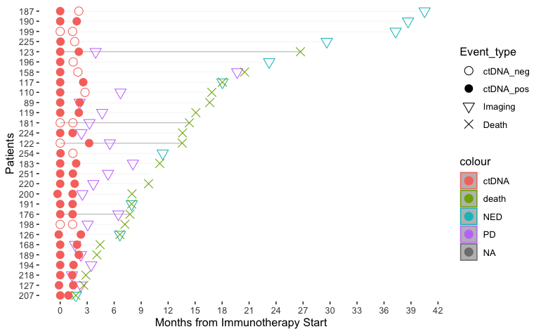

```r
setwd("~/Downloads")
clinstage <- read.csv("EORTC ICI_OP.csv")
clinstage_df <- as.data.frame(clinstage)

# Creating the basic swimmer plot
oplot <- swimmer_plot(df=clinstage_df,
                      id='PatientName',
                      end='fu.diff.months',
                      fill='gray',
                      width=.01)

# Adding themes and scales
oplot <- oplot + theme(panel.border = element_blank())
oplot <- oplot + scale_y_continuous(breaks = seq(0, 48, by = 3))
oplot <- oplot + labs(x ="Patients", y="Months from Immunotherapy Start")

# Adding swimmer points
oplot_ev1 <- oplot + swimmer_points(df_points=clinstage_df,
                                    id='PatientName',
                                    time='date.diff.months',
                                    name_shape ='Event_type',
                                    name_col = 'Event',
                                    size=3.5,fill='black')
# Optionally uncomment and use col='darkgreen' if needed

# Adding shape manual scale
oplot_ev1.1 <- oplot_ev1 + ggplot2::scale_shape_manual(name="Event_type",
                                                       values=c(1,16,6,4),
                                                       breaks=c('ctDNA_neg','ctDNA_pos','Imaging','Death'))

# Display the plot
oplot_ev1.1
```

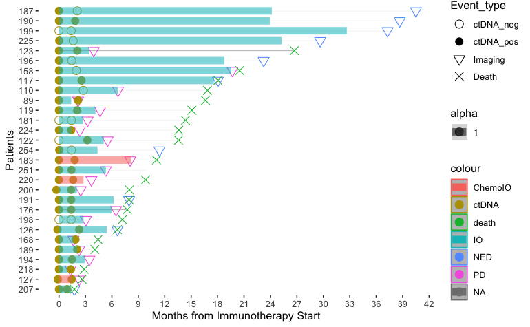

```r
                                    oplot_ev2 <- oplot_ev1.1 + swimmer_lines(df_lines=clinstage_df,
                                                                             id='PatientName',
                                                                             start='Tx_start.months',
                                                                             end='Tx_end.months',
                                                                             name_col='Tx_type',
                                                                             size=3.5,
                                                                             name_alpha = 1.0)
                                    oplot_ev2 <- oplot_ev2 + guides(linetype = guide_legend(override.aes = list(size = 5, color = "black")))
                                    oplot_ev2
```

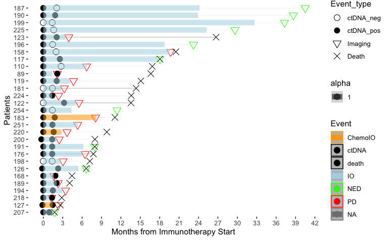

```r
oplot_ev2.2 <- oplot_ev2 + ggplot2::scale_color_manual(name="Event",values=c( "orange", "black", "black", "lightblue", "green", "red"))
oplot_ev2.2
```

#Overview plot - stratified by BOR

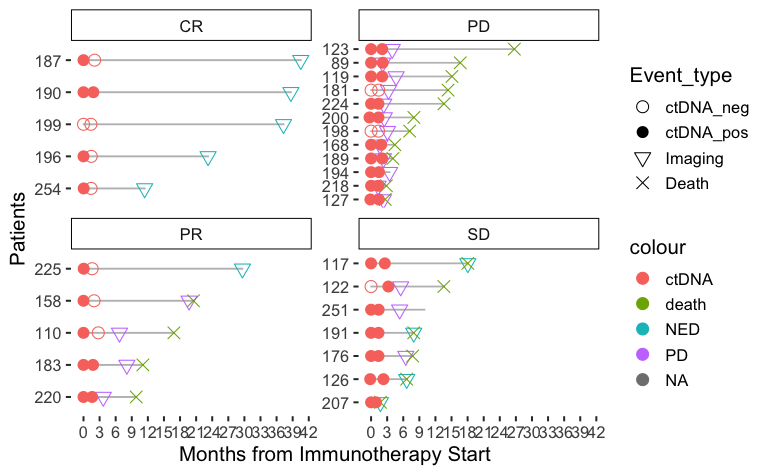

```r
setwd("~/Downloads")
clinstage <- read.csv("EORTC ICI_OP.csv")
clinstage_df <- as.data.frame(clinstage)

# Creating the basic swimmer plot
oplot_stratify <-swimmer_plot(df=clinstage_df,
                              id='PatientName',
                              end='fu.diff.months',
                              col="gray",
                              alpha=0.75,
                              width=.01,
                              base_size = 14,
                              stratify= c('RECIST'))
oplot_stratify <- oplot_stratify + theme(panel.border = element_blank())
oplot_stratify <- oplot_stratify + scale_y_continuous(breaks = seq(0, 42, by = 3))
oplot_stratify <- oplot_stratify + labs(x ="Patients" , y="Months from Immunotherapy Start")

# Adding swimmer points
oplot_ev1 <- oplot_stratify + swimmer_points(df_points=clinstage_df,
                                    id='PatientName',
                                    time='date.diff.months',
                                    name_shape ='Event_type',
                                    name_col = 'Event',
                                    size=3.5,fill='black')
# Optionally uncomment and use col='darkgreen' if needed

# Adding shape manual scale
oplot_ev1.1 <- oplot_ev1 + ggplot2::scale_shape_manual(name="Event_type",
                                                       values=c(1,16,6,4),
                                                       breaks=c('ctDNA_neg','ctDNA_pos','Imaging','Death'))

# Display the plot
oplot_ev1.1
```

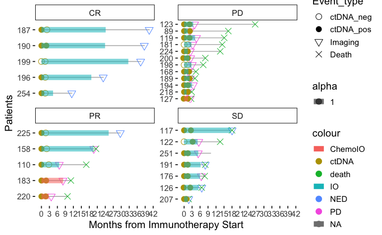

```r
                                    oplot_ev2 <- oplot_ev1.1 + swimmer_lines(df_lines=clinstage_df,
                                                                             id='PatientName',
                                                                             start='Tx_start.months',
                                                                             end='Tx_end.months',
                                                                             name_col='Tx_type',
                                                                             size=3.5,
                                                                             name_alpha = 1.0)
                                    oplot_ev2 <- oplot_ev2 + guides(linetype = guide_legend(override.aes = list(size = 5, color = "black")))
                                    oplot_ev2
```

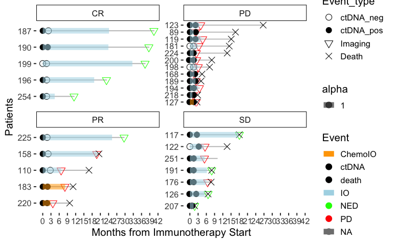

```r
oplot_ev2.2 <- oplot_ev2 + ggplot2::scale_color_manual(name="Event",values=c( "orange", "black", "black", "lightblue", "green", "red"))
oplot_ev2.2
```

#Association of Baseline ctDNA MTM levels with clinicopathological factors

```r
rm(list=ls())
setwd("~/Downloads")
circ_data <- read.csv("EORTC HNSCC ICI Clinical Data.csv")
circ_data <- circ_data[circ_data$ctDNA.available=="TRUE",]
circ_data <- circ_data[circ_data$ctDNA.Base!="",]
circ_datadf <- as.data.frame(circ_data)

tally(~cT.Status, data=circ_data, margins = TRUE)
```

```
cT.Status
cT0-T2 cT3-T4    cTx  Total
    11     17      1     29
```

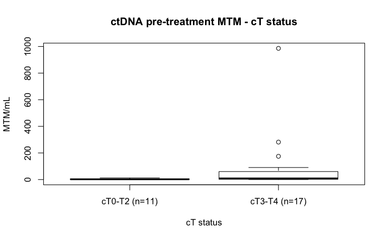

```r
circ_data$cT.Status <- factor(circ_data$cT.Status, levels = c("cT0-T2","cT3-T4"), labels = c("cT0-T2 (n=11)","cT3-T4 (n=17)"))
boxplot(ctDNA.Base.MTM~cT.Status, data=circ_data, main="ctDNA pre-treatment MTM - cT status", xlab="cT status", ylab="MTM/mL", col="white",border="black")
```

```r
m3<-wilcox.test(ctDNA.Base.MTM ~ cT.Status, data=circ_data, na.rm=TRUE, exact=FALSE, conf.int=TRUE)
print(m3)
```

```
    Wilcoxon rank sum test with continuity correction

data:  ctDNA.Base.MTM by cT.Status
W = 45.5, p-value = 0.02523
alternative hypothesis: true location shift is not equal to 0
95 percent confidence interval:
 -57.0000356  -0.7999756
sample estimates:
difference in location
             -7.400021
```

```r
tally(~cN.Status, data=circ_data, margins = TRUE)
```

```
cN.Status
   cN0 cN1-N3    cNx  Total
    12     15      2     29
```

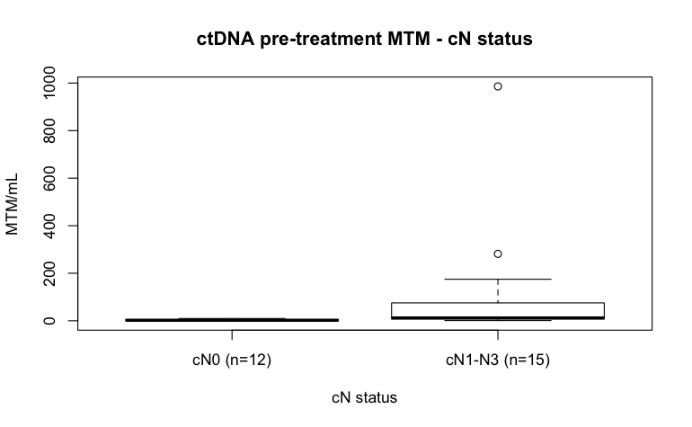

```r
circ_data$cN.Status <- factor(circ_data$cN.Status, levels = c("cN0","cN1-N3"), labels = c("cN0 (n=12)","cN1-N3 (n=15)"))
boxplot(ctDNA.Base.MTM~cN.Status, data=circ_data, main="ctDNA pre-treatment MTM - cN status", xlab="cN status", ylab="MTM/mL", col="white",border="black")
```

```r
m4<-wilcox.test(ctDNA.Base.MTM ~ cN.Status, data=circ_data, na.rm=TRUE, exact=FALSE, conf.int=TRUE)
print(m4)
```

```
    Wilcoxon rank sum test with continuity correction

data:  ctDNA.Base.MTM by cN.Status
W = 32.5, p-value = 0.005379
alternative hypothesis: true location shift is not equal to 0
95 percent confidence interval:
 -60.200006  -3.299997
sample estimates:
difference in location
             -10.15193
```

#Median MTM/mL levels for ctDNA positive pts pre-treatment

```r
rm(list=ls())
setwd("~/Downloads")
circ_data <- read.csv("EORTC HNSCC ICI Clinical Data.csv")
circ_data <- circ_data[circ_data$ctDNA.available=="TRUE",]
circ_data <- circ_data[circ_data$ctDNA.Base!="",]
circ_data <- circ_data[circ_data$ctDNA.Base=="POSITIVE",]

median_ctDNA <- median(circ_data$ctDNA.Base.MTM, na.rm = TRUE)
range_ctDNA <- range(circ_data$ctDNA.Base.MTM, na.rm = TRUE)
cat("Median MTM/mL post-treatment:", median_ctDNA, "\n")
```

[output not shown]

```r
cat("Range MTM/mL post-treatment:", range_ctDNA[1], "-", range_ctDNA[2], "\n")
```

[output not shown]

#Median MTM/mL levels for ctDNA positive pts post-treatment

```r
rm(list=ls())
setwd("~/Downloads")
circ_data <- read.csv("EORTC HNSCC ICI Clinical Data.csv")
circ_data <- circ_data[circ_data$ctDNA.available=="TRUE",]
circ_data <- circ_data[circ_data$ctDNA.postTx!="",]
circ_data <- circ_data[circ_data$ctDNA.postTx=="POSITIVE",]

median_ctDNA <- median(circ_data$ctDNA.postTx.MTM, na.rm = TRUE)
range_ctDNA <- range(circ_data$ctDNA.postTx.MTM, na.rm = TRUE)
cat("Median MTM/mL post-treatment:", median_ctDNA, "\n")
```

```
Median MTM/mL post-treatment: 7.9
```

```r
cat("Range MTM/mL post-treatment:", range_ctDNA[1], "-", range_ctDNA[2], "\n")
```

```
Range MTM/mL post-treatment: 0.1 - 737.8
```

```r
rm(list=ls())
setwd("~/Downloads")
circ_data <- read.csv("EORTC HNSCC ICI Clinical Data.csv")
circ_data <- circ_data[circ_data$ctDNA.available=="TRUE",]
circ_data <- circ_data[circ_data$ctDNA.postTx!="",]
circ_data <- circ_data[circ_data$ctDNA.postTx=="NEGATIVE",]
circ_data <- circ_data[circ_data$PFS.Event=="TRUE",]

median_PFS <- median(circ_data$PFS.months, na.rm = TRUE)
range_PFS <- range(circ_data$PFS.months, na.rm = TRUE)
cat("Median PFS:", median_PFS, "\n")
```

```
Median PFS: 4.977494
```

```r
cat("Range PFS:", range_PFS[1], "-", range_PFS[2], "\n")
```

```
Range PFS: 3.055492 - 19.67999
```

#PFS by ctDNA status post/during-ICI

```r
rm(list=ls())
setwd("~/Downloads")
circ_data <- read.csv("EORTC HNSCC ICI Clinical Data.csv")
circ_data <- circ_data[circ_data$ctDNA.available=="TRUE",]
circ_data <- circ_data[circ_data$ctDNA.postTx!="",]
circ_datadf <- as.data.frame(circ_data)

survfit(Surv(time = circ_data$PFS.months, event = circ_data$PFS.Event)~ctDNA.postTx, data = circ_data)
```

```
Call: survfit(formula = Surv(time = circ_data$PFS.months, event = circ_data$PFS.Event) ~
    ctDNA.postTx, data = circ_data)

                       n events median 0.95LCL 0.95UCL
ctDNA.postTx=NEGATIVE  9      4     NA    6.70      NA
ctDNA.postTx=POSITIVE 20     19   3.81    2.37    6.64
```

```r
event_summary <- circ_data %>%
  group_by(ctDNA.postTx) %>%
  summarise(
    Total = n(),
    Events = sum(PFS.Event),
    Fraction = Events / n(),
    Percentage = (Events / n()) * 100
  )
print(event_summary)
```

| ctDNA.postTx | Total | Events | Fraction | Percentage |
| --- | --- | --- | --- | --- |
| NEGATIVE | 9 | 4 | 0.4444444 | 44.44444 |
| POSITIVE | 20 | 19 | 0.9500000 | 95.00000 |

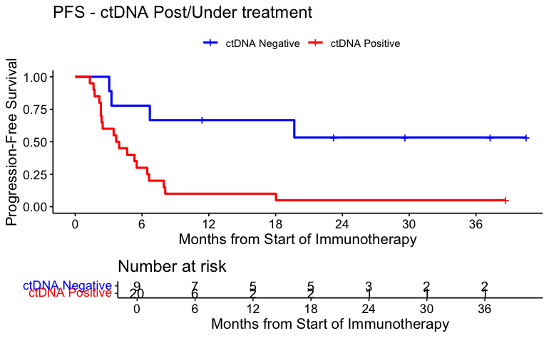

```r
surv_object <-Surv(time = circ_data$PFS.months, event = circ_data$PFS.Event)
KM_curve <- survfit(surv_object ~ ctDNA.postTx, data = circ_data,conf.int=0.95,conf.type="log-log")
ggsurvplot(KM_curve, data = circ_data, pval = FALSE, conf.int = FALSE, risk.table = TRUE, break.time.by=6, palette=c("blue","red"), title="PFS - ctDNA Post/Under treatment", ylab= "Progression-Free Survival", xlab="Months from Start of Immunotherapy", legend.labs=c("ctDNA Negative", "ctDNA Positive"), legend.title="")
```

```r
summary(KM_curve, times= c(0, 12, 24, 36))
```

```
Call: survfit(formula = surv_object ~ ctDNA.postTx, data = circ_data,
    conf.int = 0.95, conf.type = "log-log")

                ctDNA.postTx=NEGATIVE
 time n.risk n.event survival std.err lower 95% CI upper 95% CI
    0      9       0    1.000   0.000        1.000        1.000
   12      5       3    0.667   0.157        0.282        0.878
   24      3       1    0.533   0.173        0.177        0.796
   36      2       0    0.533   0.173        0.177        0.796

                ctDNA.postTx=POSITIVE
 time n.risk n.event survival std.err lower 95% CI upper 95% CI
    0     20       0     1.00  0.0000      1.00000        1.000
   12      2      18     0.10  0.0671      0.01698        0.272
   24      1       1     0.05  0.0487      0.00345        0.205
   36      1       0     0.05  0.0487      0.00345        0.205
```

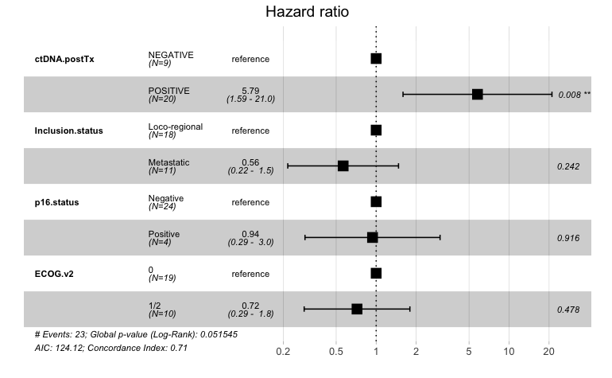

```r
circ_data$ctDNA.postTx <- factor(circ_data$ctDNA.postTx, levels=c("NEGATIVE","POSITIVE"))
circ_data$Inclusion.status <- factor(circ_data$Inclusion.status, levels = c("Loco-regional", "Metastatic"))
circ_data$p16.status <- factor(circ_data$p16.status, levels = c("Negative", "Positive"))
circ_data$ECOG.v2 <- factor(circ_data$ECOG.v2, levels = c("0", "1/2"))
cox_fit <- coxph(surv_object ~ ctDNA.postTx + Inclusion.status + p16.status + ECOG.v2, data=circ_data)
ggforest(cox_fit,data = circ_data)
```

```r
summary(cox_fit)
```

```
Call:
coxph(formula = surv_object ~ ctDNA.postTx + Inclusion.status +
    p16.status + ECOG.v2, data = circ_data)

  n= 28, number of events= 23
   (1 observation deleted due to missingness)

                              coef exp(coef) se(coef)      z Pr(>|z|)
ctDNA.postTxPOSITIVE        1.7556    5.7870   0.6584  2.666  0.00767 **
Inclusion.statusMetastatic -0.5723    0.5642   0.4895 -1.169  0.24237
p16.statusPositive         -0.0633    0.9387   0.5971 -0.106  0.91557
ECOG.v21/2                 -0.3318    0.7176   0.4674 -0.710  0.47770
---
Signif. codes:  0 ‘***’ 0.001 ‘**’ 0.01 ‘*’ 0.05 ‘.’ 0.1 ‘ ’ 1

                           exp(coef) exp(-coef) lower .95 upper .95
ctDNA.postTxPOSITIVE          5.7870     0.1728    1.5922    21.033
Inclusion.statusMetastatic    0.5642     1.7724    0.2162     1.473
p16.statusPositive            0.9387     1.0653    0.2912     3.025
ECOG.v21/2                    0.7176     1.3935    0.2871     1.794

Concordance= 0.708  (se = 0.053 )
Likelihood ratio test= 9.41  on 4 df,   p=0.05
Wald test            = 7.4  on 4 df,   p=0.1
Score (logrank) test = 8.26  on 4 df,   p=0.08
```

```r
cox_fit_summary <- summary(cox_fit)

circ_data$ctDNA.postTx <- factor(circ_data$ctDNA.postTx, levels = c("NEGATIVE", "POSITIVE"), labels = c("Negative", "Positive"))
circ_data$PFS.Event <- factor(circ_data$PFS.Event, levels = c("FALSE", "TRUE"), labels = c("No Progression", "Progression"))
contingency_table <- table(circ_data$ctDNA.postTx, circ_data$PFS.Event)
chi_square_test <- chisq.test(contingency_table)
```

```
G2;H2;Warningh in stats::chisq.test(x, y, ...) :
  Chi-squared approximation may be incorrectg
```

```r
print(chi_square_test)
```

```
    Pearson's Chi-squared test with Yates' continuity correction

data:  contingency_table
X-squared = 6.8323, df = 1, p-value = 0.008952
```

```r
fisher_exact_test <- fisher.test(contingency_table)
print(fisher_exact_test)
```

```
    Fisher's Exact Test for Count Data

data:  contingency_table
p-value = 0.005482
alternative hypothesis: true odds ratio is not equal to 1
95 percent confidence interval:
    1.68957 1169.09723
sample estimates:
odds ratio
  20.33413
```

```r
print(contingency_table)
```

```
           No Progression Progression
  Negative              5           4
  Positive              1          19
```

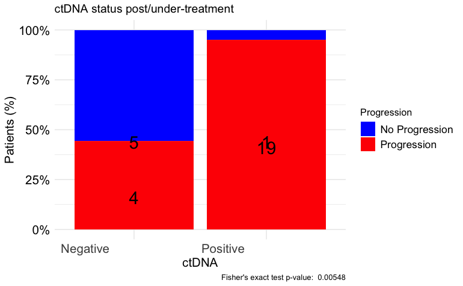

```r
table_df <- as.data.frame(contingency_table)
table_df$Total <- ave(table_df$Freq, table_df$Var1, FUN = sum)
table_df$Percentage <- table_df$Freq / table_df$Total
table_df$MiddlePercentage <- table_df$Percentage / 2
ggplot(table_df, aes(x = Var1, y = Percentage, fill = Var2)) +
  geom_bar(stat = "identity") +
  geom_text(aes(y = MiddlePercentage, label = Freq), position = "stack", color = "black", vjust = 1.5, size = 7) +
  theme_minimal() +
  labs(title = "ctDNA status post/under-treatment",
       x = "ctDNA",
       y = "Patients (%)",
       fill = "Progression",
       caption = paste("Fisher's exact test p-value: ", format.pval(fisher_exact_test$p.value))) +
  scale_y_continuous(labels = scales::percent_format()) +
  scale_fill_manual(values = c("No Progression" = "blue", "Progression" = "red")) + # define custom colors
  theme(axis.text.x = element_text(angle = 0, hjust = 1.5, size = 14), # increase x-axis text size
        axis.text.y = element_text(size = 14, color = "black"), # increase y-axis text size
        axis.title.x = element_text(size = 14, color = "black"), # increase x-axis label size
        axis.title.y = element_text(size = 14, color = "black"), # increase y-axis label size
        legend.text = element_text(size = 12, color = "black"))  # increase Progression label size
```

#OS by ctDNA status post/during-ICI

```r
rm(list=ls())
setwd("~/Downloads")
circ_data <- read.csv("EORTC HNSCC ICI Clinical Data.csv")
circ_data <- circ_data[circ_data$ctDNA.available=="TRUE",]
circ_data <- circ_data[circ_data$ctDNA.postTx!="",]
circ_datadf <- as.data.frame(circ_data)

survfit(Surv(time = circ_data$OS.months, event = circ_data$OS.Event)~ctDNA.postTx, data = circ_data)
```

```
Call: survfit(formula = Surv(time = circ_data$OS.months, event = circ_data$OS.Event) ~
    ctDNA.postTx, data = circ_data)

                       n events median 0.95LCL 0.95UCL
ctDNA.postTx=NEGATIVE  9      4     NA   16.85      NA
ctDNA.postTx=POSITIVE 20     17   10.4    7.75      18
```

```r
event_summary <- circ_data %>%
  group_by(ctDNA.postTx) %>%
  summarise(
    Total = n(),
    Events = sum(OS.Event),
    Fraction = Events / n(),
    Percentage = (Events / n()) * 100
  )
print(event_summary)
```

| ctDNA.postTx | Total | Events | Fraction | Percentage |
| --- | --- | --- | --- | --- |
| NEGATIVE | 9 | 4 | 0.4444444 | 44.44444 |
| POSITIVE | 20 | 17 | 0.8500000 | 85.00000 |

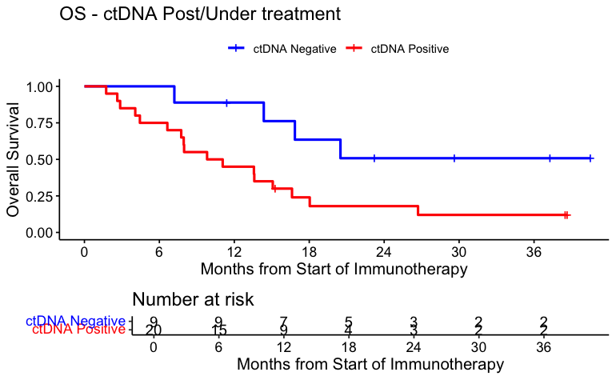

```r
surv_object <-Surv(time = circ_data$OS.months, event = circ_data$OS.Event)
KM_curve <- survfit(surv_object ~ ctDNA.postTx, data = circ_data,conf.int=0.95,conf.type="log-log")
ggsurvplot(KM_curve, data = circ_data, pval = FALSE, conf.int = FALSE, risk.table = TRUE, break.time.by=6, palette=c("blue","red"), title="OS - ctDNA Post/Under treatment", ylab= "Overall Survival", xlab="Months from Start of Immunotherapy", legend.labs=c("ctDNA Negative", "ctDNA Positive"), legend.title="")
```

```r
summary(KM_curve, times= c(12, 24, 36))
```

```
Call: survfit(formula = surv_object ~ ctDNA.postTx, data = circ_data,
    conf.int = 0.95, conf.type = "log-log")

                ctDNA.postTx=NEGATIVE
 time n.risk n.event survival std.err lower 95% CI upper 95% CI
   12      7       1    0.889   0.105        0.433        0.984
   24      3       3    0.508   0.177        0.157        0.781
   36      2       0    0.508   0.177        0.157        0.781

                ctDNA.postTx=POSITIVE
 time n.risk n.event survival std.err lower 95% CI upper 95% CI
   12      9      11     0.45  0.1112       0.2311        0.647
   24      3       5     0.18  0.0900       0.0480        0.380
   36      2       1     0.12  0.0775       0.0213        0.311
```

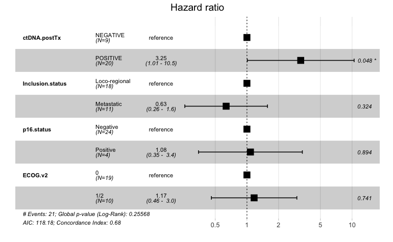

```r
circ_data$ctDNA.postTx <- factor(circ_data$ctDNA.postTx, levels=c("NEGATIVE","POSITIVE"))
circ_data$Inclusion.status <- factor(circ_data$Inclusion.status, levels = c("Loco-regional", "Metastatic"))
circ_data$p16.status <- factor(circ_data$p16.status, levels = c("Negative", "Positive"))
circ_data$ECOG.v2 <- factor(circ_data$ECOG.v2, levels = c("0", "1/2"))
cox_fit <- coxph(surv_object ~ ctDNA.postTx + Inclusion.status + p16.status + ECOG.v2, data=circ_data)
ggforest(cox_fit,data = circ_data)
```

```r
summary(cox_fit)
```

```
Call:
coxph(formula = surv_object ~ ctDNA.postTx + Inclusion.status +
    p16.status + ECOG.v2, data = circ_data)

  n= 28, number of events= 21
   (1 observation deleted due to missingness)

                               coef exp(coef) se(coef)      z Pr(>|z|)
ctDNA.postTxPOSITIVE        1.17775   3.24706  0.59654  1.974   0.0483 *
Inclusion.statusMetastatic -0.45503   0.63443  0.46155 -0.986   0.3242
p16.statusPositive          0.07725   1.08031  0.57990  0.133   0.8940
ECOG.v21/2                  0.15760   1.17070  0.47744  0.330   0.7413
---
Signif. codes:  0 ‘***’ 0.001 ‘**’ 0.01 ‘*’ 0.05 ‘.’ 0.1 ‘ ’ 1

                           exp(coef) exp(-coef) lower .95 upper .95
ctDNA.postTxPOSITIVE          3.2471     0.3080    1.0086    10.454
Inclusion.statusMetastatic    0.6344     1.5762    0.2567     1.568
p16.statusPositive            1.0803     0.9257    0.3467     3.366
ECOG.v21/2                    1.1707     0.8542    0.4593     2.984

Concordance= 0.678  (se = 0.052 )
Likelihood ratio test= 5.32  on 4 df,   p=0.3
Wald test            = 4.59  on 4 df,   p=0.3
Score (logrank) test = 4.92  on 4 df,   p=0.3
```

```r
cox_fit_summary <- summary(cox_fit)

circ_data$ctDNA.postTx <- factor(circ_data$ctDNA.postTx, levels = c("NEGATIVE", "POSITIVE"), labels = c("Negative", "Positive"))
circ_data$OS.Event <- factor(circ_data$OS.Event, levels = c("FALSE", "TRUE"), labels = c("Alive", "Deceased"))
contingency_table <- table(circ_data$ctDNA.postTx, circ_data$OS.Event)
chi_square_test <- chisq.test(contingency_table)
```

```
G2;H2;Warningh in stats::chisq.test(x, y, ...) :
  Chi-squared approximation may be incorrectg
```

```r
print(chi_square_test)
```

```
    Pearson's Chi-squared test with Yates' continuity correction

data:  contingency_table
X-squared = 3.2819, df = 1, p-value = 0.07005
```

```r
fisher_exact_test <- fisher.test(contingency_table)
print(fisher_exact_test)
```

```
    Fisher's Exact Test for Count Data

data:  contingency_table
p-value = 0.0667
alternative hypothesis: true odds ratio is not equal to 1
95 percent confidence interval:
  0.8624077 62.5051555
sample estimates:
odds ratio
  6.505452
```

```r
print(contingency_table)
```

```
           Alive Deceased
  Negative     5        4
  Positive     3       17
```

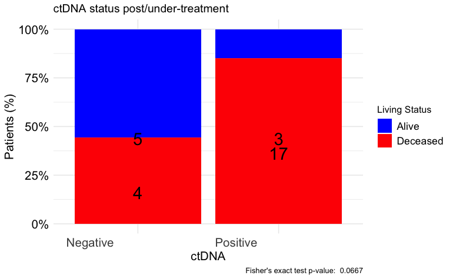

```r
table_df <- as.data.frame(contingency_table)
table_df$Total <- ave(table_df$Freq, table_df$Var1, FUN = sum)
table_df$Percentage <- table_df$Freq / table_df$Total
table_df$MiddlePercentage <- table_df$Percentage / 2
ggplot(table_df, aes(x = Var1, y = Percentage, fill = Var2)) +
  geom_bar(stat = "identity") +
  geom_text(aes(y = MiddlePercentage, label = Freq), position = "stack", color = "black", vjust = 1.5, size = 7) +
  theme_minimal() +
  labs(title = "ctDNA status post/under-treatment",
       x = "ctDNA",
       y = "Patients (%)",
       fill = "Living Status",
       caption = paste("Fisher's exact test p-value: ", format.pval(fisher_exact_test$p.value))) +
  scale_y_continuous(labels = scales::percent_format()) +
  scale_fill_manual(values = c("Alive" = "blue", "Deceased" = "red")) + # define custom colors
  theme(axis.text.x = element_text(angle = 0, hjust = 1.5, size = 14), # increase x-axis text size
        axis.text.y = element_text(size = 14, color = "black"), # increase y-axis text size
        axis.title.x = element_text(size = 14, color = "black"), # increase x-axis label size
        axis.title.y = element_text(size = 14, color = "black"), # increase y-axis label size
        legend.text = element_text(size = 12, color = "black"))  # increase Progression label size
```

#Association of ctDNA status post/during-ICI with BOR

```r
rm(list=ls())
setwd("~/Downloads")
circ_data <- read.csv("EORTC HNSCC ICI Clinical Data.csv")
circ_data <- circ_data[circ_data$ctDNA.available=="TRUE",]
circ_datadf <- as.data.frame(circ_data)

circ_data$ctDNA.postTx <- factor(circ_data$ctDNA.postTx, levels = c("NEGATIVE", "POSITIVE"), labels = c("Negative", "Positive"))
circ_data$RESIST <- factor(circ_data$RESIST, levels = c("CR", "PR", "SD", "PD"))
contingency_table <- table(circ_data$ctDNA.postTx, circ_data$RESIST)
chi_square_test <- chisq.test(contingency_table)
```

```
G2;H2;Warningh in stats::chisq.test(x, y, ...) :
  Chi-squared approximation may be incorrectg
```

```r
print(chi_square_test)
```

```
    Pearson's Chi-squared test

data:  contingency_table
X-squared = 11.869, df = 3, p-value = 0.007847
```

```r
fisher_exact_test <- fisher.test(contingency_table)
print(fisher_exact_test)
```

```
    Fisher's Exact Test for Count Data

data:  contingency_table
p-value = 0.006541
alternative hypothesis: two.sided
```

```r
print(contingency_table)
```

```
           CR PR SD PD
  Negative  4  3  0  2
  Positive  1  2  7 10
```

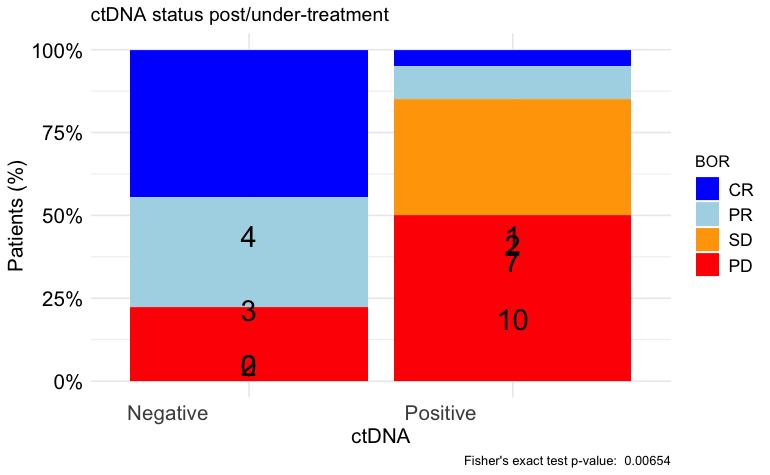

```r
table_df <- as.data.frame(contingency_table)
table_df$Total <- ave(table_df$Freq, table_df$Var1, FUN = sum)
table_df$Percentage <- table_df$Freq / table_df$Total
table_df$MiddlePercentage <- table_df$Percentage / 2
ggplot(table_df, aes(x = Var1, y = Percentage, fill = Var2)) +
  geom_bar(stat = "identity") +
  geom_text(aes(y = MiddlePercentage, label = Freq), position = "stack", color = "black", vjust = 1.5, size = 7) +
  theme_minimal() +
  labs(title = "ctDNA status post/under-treatment",
       x = "ctDNA",
       y = "Patients (%)",
       fill = "BOR",
       caption = paste("Fisher's exact test p-value: ", format.pval(fisher_exact_test$p.value))) +
  scale_y_continuous(labels = scales::percent_format()) +
  scale_fill_manual(values = c("CR" = "blue", "PR" = "lightblue", "SD" = "orange", "PD" = "red")) + # define custom colors
  theme(axis.text.x = element_text(angle = 0, hjust = 1.5, size = 14), # increase x-axis text size
        axis.text.y = element_text(size = 14, color = "black"), # increase y-axis text size
        axis.title.x = element_text(size = 14, color = "black"), # increase x-axis label size
        axis.title.y = element_text(size = 14, color = "black"), # increase y-axis label size
        legend.text = element_text(size = 12, color = "black"))  # increase Progression label size
```

#PFS by ctDNA kinetics post/during-ICI

```r
rm(list=ls())
setwd("~/Downloads")
circ_data <- read.csv("EORTC HNSCC ICI Clinical Data.csv")
circ_data <- circ_data[circ_data$ctDNA.available=="TRUE",]
circ_data <- circ_data[circ_data$ΔctDNA!="",]
circ_datadf <- as.data.frame(circ_data)

survfit(Surv(time = circ_data$PFS.months, event = circ_data$PFS.Event)~ΔctDNA, data = circ_data)
```

```
Call: survfit(formula = Surv(time = circ_data$PFS.months, event = circ_data$PFS.Event) ~
    ΔctDNA, data = circ_data)

                 n events median 0.95LCL 0.95UCL
ΔctDNA=NEGATIVE 13      8  18.04     6.7      NA
ΔctDNA=POSITIVE 12     12   2.41     2.3      NA
```

```r
event_summary <- circ_data %>%
  group_by(ΔctDNA) %>%
  summarise(
    Total = n(),
    Events = sum(PFS.Event),
    Fraction = Events / n(),
    Percentage = (Events / n()) * 100
  )
print(event_summary)
```

| ΔctDNA | Total | Events | Fraction | Percentage |
| --- | --- | --- | --- | --- |
| NEGATIVE | 13 | 8 | 0.6153846 | 61.53846 |
| POSITIVE | 12 | 12 | 1.0000000 | 100.00000 |

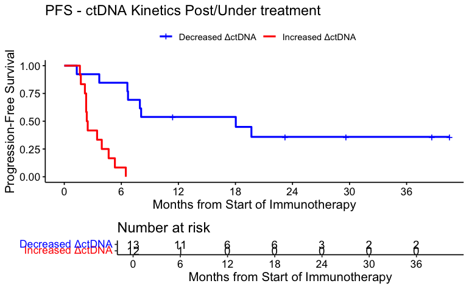

```r
surv_object <-Surv(time = circ_data$PFS.months, event = circ_data$PFS.Event)
KM_curve <- survfit(surv_object ~ ΔctDNA, data = circ_data,conf.int=0.95,conf.type="log-log")
ggsurvplot(KM_curve, data = circ_data, pval = FALSE, conf.int = FALSE, risk.table = TRUE, break.time.by=6, palette=c("blue","red"), title="PFS - ctDNA Kinetics Post/Under treatment", ylab= "Progression-Free Survival", xlab="Months from Start of Immunotherapy", legend.labs=c("Decreased ΔctDNA", "Increased ΔctDNA"), legend.title="")
```

```r
summary(KM_curve, times= c(0, 12, 24, 36))
```

```
Call: survfit(formula = surv_object ~ ΔctDNA, data = circ_data, conf.int = 0.95,
    conf.type = "log-log")

                ΔctDNA=NEGATIVE
 time n.risk n.event survival std.err lower 95% CI upper 95% CI
    0     13       0    1.000   0.000        1.000        1.000
   12      6       6    0.538   0.138        0.248        0.760
   24      3       2    0.359   0.139        0.117        0.613
   36      2       0    0.359   0.139        0.117        0.613

                ΔctDNA=POSITIVE
        time       n.risk      n.event     survival      std.err lower 95% CI upper 95% CI
           0           12            0            1            0            1            1
```

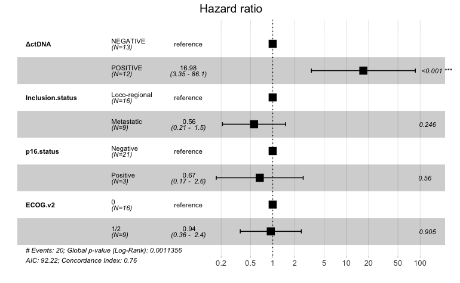

```r
circ_data$ΔctDNA <- factor(circ_data$ΔctDNA, levels=c("NEGATIVE","POSITIVE"))
circ_data$Inclusion.status <- factor(circ_data$Inclusion.status, levels = c("Loco-regional", "Metastatic"))
circ_data$p16.status <- factor(circ_data$p16.status, levels = c("Negative", "Positive"))
circ_data$ECOG.v2 <- factor(circ_data$ECOG.v2, levels = c("0", "1/2"))
cox_fit <- coxph(surv_object ~ ΔctDNA + Inclusion.status + p16.status + ECOG.v2, data=circ_data)
ggforest(cox_fit,data = circ_data)
```

```r
summary(cox_fit)
```

```
Call:
coxph(formula = surv_object ~ ΔctDNA + Inclusion.status + p16.status +
    ECOG.v2, data = circ_data)

  n= 24, number of events= 20
   (1 observation deleted due to missingness)

                               coef exp(coef) se(coef)      z Pr(>|z|)
ΔctDNAPOSITIVE              2.83213  16.98167  0.82815  3.420 0.000627 ***
Inclusion.statusMetastatic -0.58271   0.55838  0.50257 -1.159 0.246269
p16.statusPositive         -0.40417   0.66753  0.69270 -0.583 0.559573
ECOG.v21/2                 -0.05836   0.94331  0.48669 -0.120 0.904549
---
Signif. codes:  0 ‘***’ 0.001 ‘**’ 0.01 ‘*’ 0.05 ‘.’ 0.1 ‘ ’ 1

                           exp(coef) exp(-coef) lower .95 upper .95
ΔctDNAPOSITIVE               16.9817    0.05889    3.3501    86.081
Inclusion.statusMetastatic    0.5584    1.79089    0.2085     1.495
p16.statusPositive            0.6675    1.49806    0.1717     2.595
ECOG.v21/2                    0.9433    1.06010    0.3634     2.449

Concordance= 0.758  (se = 0.048 )
Likelihood ratio test= 18.18  on 4 df,   p=0.001
Wald test            = 11.96  on 4 df,   p=0.02
Score (logrank) test = 17.74  on 4 df,   p=0.001
```

```r
cox_fit_summary <- summary(cox_fit)

circ_data$ΔctDNA <- factor(circ_data$ΔctDNA, levels = c("NEGATIVE", "POSITIVE"), labels = c("Decreased", "Increased"))
circ_data$PFS.Event <- factor(circ_data$PFS.Event, levels = c("FALSE", "TRUE"), labels = c("No Progression", "Progression"))
contingency_table <- table(circ_data$ΔctDNA, circ_data$PFS.Event)
chi_square_test <- chisq.test(contingency_table)
```

```
G2;H2;Warningh in stats::chisq.test(x, y, ...) :
  Chi-squared approximation may be incorrectg
```

```r
print(chi_square_test)
```

```
    Pearson's Chi-squared test with Yates' continuity correction

data:  contingency_table
X-squared = 3.6158, df = 1, p-value = 0.05723
```

```r
fisher_exact_test <- fisher.test(contingency_table)
print(fisher_exact_test)
```

```
    Fisher's Exact Test for Count Data

data:  contingency_table
p-value = 0.03913
alternative hypothesis: true odds ratio is not equal to 1
95 percent confidence interval:
 1.013281      Inf
sample estimates:
odds ratio
       Inf
```

```r
print(contingency_table)
```

```
            No Progression Progression
  Decreased              5           8
  Increased              0          12
```

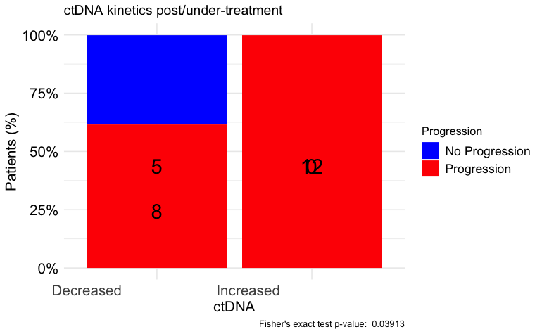

```r
table_df <- as.data.frame(contingency_table)
table_df$Total <- ave(table_df$Freq, table_df$Var1, FUN = sum)
table_df$Percentage <- table_df$Freq / table_df$Total
table_df$MiddlePercentage <- table_df$Percentage / 2
ggplot(table_df, aes(x = Var1, y = Percentage, fill = Var2)) +
  geom_bar(stat = "identity") +
  geom_text(aes(y = MiddlePercentage, label = Freq), position = "stack", color = "black", vjust = 1.5, size = 7) +
  theme_minimal() +
  labs(title = "ctDNA kinetics post/under-treatment",
       x = "ctDNA",
       y = "Patients (%)",
       fill = "Progression",
       caption = paste("Fisher's exact test p-value: ", format.pval(fisher_exact_test$p.value))) +
  scale_y_continuous(labels = scales::percent_format()) +
  scale_fill_manual(values = c("No Progression" = "blue", "Progression" = "red")) + # define custom colors
  theme(axis.text.x = element_text(angle = 0, hjust = 1.5, size = 14), # increase x-axis text size
        axis.text.y = element_text(size = 14, color = "black"), # increase y-axis text size
        axis.title.x = element_text(size = 14, color = "black"), # increase x-axis label size
        axis.title.y = element_text(size = 14, color = "black"), # increase y-axis label size
        legend.text = element_text(size = 12, color = "black"))  # increase Progression label size
```

#OS by ctDNA kinetics post/during-ICI

```r
rm(list=ls())
setwd("~/Downloads")
circ_data <- read.csv("EORTC HNSCC ICI Clinical Data.csv")
circ_data <- circ_data[circ_data$ctDNA.available=="TRUE",]
circ_data <- circ_data[circ_data$ΔctDNA!="",]
circ_datadf <- as.data.frame(circ_data)

survfit(Surv(time = circ_data$OS.months, event = circ_data$OS.Event)~ΔctDNA, data = circ_data)
```

```
Call: survfit(formula = Surv(time = circ_data$OS.months, event = circ_data$OS.Event) ~
    ΔctDNA, data = circ_data)

                 n events median 0.95LCL 0.95UCL
ΔctDNA=NEGATIVE 13      8   18.0    9.82      NA
ΔctDNA=POSITIVE 12     10   10.8    4.44      NA
```

```r
event_summary <- circ_data %>%
  group_by(ΔctDNA) %>%
  summarise(
    Total = n(),
    Events = sum(OS.Event),
    Fraction = Events / n(),
    Percentage = (Events / n()) * 100
  )
print(event_summary)
```

| ΔctDNA | Total | Events | Fraction | Percentage |
| --- | --- | --- | --- | --- |
| NEGATIVE | 13 | 8 | 0.6153846 | 61.53846 |
| POSITIVE | 12 | 10 | 0.8333333 | 83.33333 |

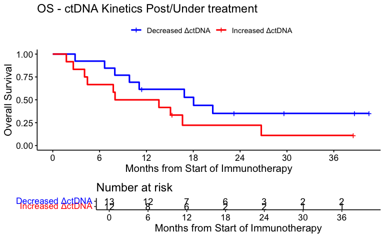

```r
surv_object <-Surv(time = circ_data$OS.months, event = circ_data$OS.Event)
KM_curve <- survfit(surv_object ~ ΔctDNA, data = circ_data,conf.int=0.95,conf.type="log-log")
ggsurvplot(KM_curve, data = circ_data, pval = FALSE, conf.int = FALSE, risk.table = TRUE, break.time.by=6, palette=c("blue","red"), title="OS - ctDNA Kinetics Post/Under treatment", ylab= "Overall Survival", xlab="Months from Start of Immunotherapy", legend.labs=c("Decreased ΔctDNA", "Increased ΔctDNA"), legend.title="")
```

```r
summary(KM_curve, times= c(0, 12, 24, 36))
```

```
Call: survfit(formula = surv_object ~ ΔctDNA, data = circ_data, conf.int = 0.95,
    conf.type = "log-log")

                ΔctDNA=NEGATIVE
 time n.risk n.event survival std.err lower 95% CI upper 95% CI
    0     13       0    1.000   0.000        1.000        1.000
   12      7       5    0.615   0.135        0.308        0.818
   24      3       3    0.352   0.139        0.112        0.607
   36      2       0    0.352   0.139        0.112        0.607

                ΔctDNA=POSITIVE
 time n.risk n.event survival std.err lower 95% CI upper 95% CI
    0     12       0    1.000   0.000      1.00000        1.000
   12      6       6    0.500   0.144      0.20848        0.736
   24      2       3    0.222   0.128      0.04111        0.492
   36      1       1    0.111   0.101      0.00701        0.378
```

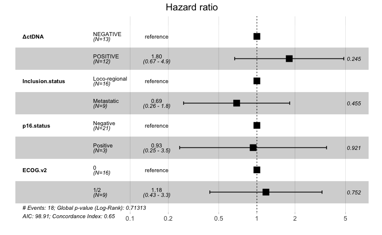

```r
circ_data$ΔctDNA <- factor(circ_data$ΔctDNA, levels=c("NEGATIVE","POSITIVE"))
circ_data$Inclusion.status <- factor(circ_data$Inclusion.status, levels = c("Loco-regional", "Metastatic"))
circ_data$p16.status <- factor(circ_data$p16.status, levels = c("Negative", "Positive"))
circ_data$ECOG.v2 <- factor(circ_data$ECOG.v2, levels = c("0", "1/2"))
cox_fit <- coxph(surv_object ~ ΔctDNA + Inclusion.status + p16.status + ECOG.v2, data=circ_data)
ggforest(cox_fit,data = circ_data)
```

```r
summary(cox_fit)
```

```
Call:
coxph(formula = surv_object ~ ΔctDNA + Inclusion.status + p16.status +
    ECOG.v2, data = circ_data)

  n= 24, number of events= 18
   (1 observation deleted due to missingness)

                               coef exp(coef) se(coef)      z Pr(>|z|)
ΔctDNAPOSITIVE              0.58779   1.80000  0.50575  1.162    0.245
Inclusion.statusMetastatic -0.36730   0.69261  0.49166 -0.747    0.455
p16.statusPositive         -0.06789   0.93436  0.68080 -0.100    0.921
ECOG.v21/2                  0.16464   1.17897  0.52011  0.317    0.752

                           exp(coef) exp(-coef) lower .95 upper .95
ΔctDNAPOSITIVE                1.8000     0.5556    0.6680     4.850
Inclusion.statusMetastatic    0.6926     1.4438    0.2642     1.815
p16.statusPositive            0.9344     1.0702    0.2460     3.548
ECOG.v21/2                    1.1790     0.8482    0.4254     3.268

Concordance= 0.651  (se = 0.062 )
Likelihood ratio test= 2.12  on 4 df,   p=0.7
Wald test            = 2.1  on 4 df,   p=0.7
Score (logrank) test = 2.15  on 4 df,   p=0.7
```

```r
cox_fit_summary <- summary(cox_fit)

circ_data$ΔctDNA <- factor(circ_data$ΔctDNA, levels = c("NEGATIVE", "POSITIVE"), labels = c("Decreased", "Increased"))
circ_data$OS.Event <- factor(circ_data$OS.Event, levels = c("FALSE", "TRUE"), labels = c("Alive", "Deceased"))
contingency_table <- table(circ_data$ΔctDNA, circ_data$OS.Event)
chi_square_test <- chisq.test(contingency_table)
```

```
G2;H2;Warningh in stats::chisq.test(x, y, ...) :
  Chi-squared approximation may be incorrectg
```

```r
print(chi_square_test)
```

```
    Pearson's Chi-squared test with Yates' continuity correction

data:  contingency_table
X-squared = 0.58792, df = 1, p-value = 0.4432
```

```r
fisher_exact_test <- fisher.test(contingency_table)
print(fisher_exact_test)
```

```
    Fisher's Exact Test for Count Data

data:  contingency_table
p-value = 0.3783
alternative hypothesis: true odds ratio is not equal to 1
95 percent confidence interval:
  0.363132 39.390335
sample estimates:
odds ratio
  2.985191
```

```r
print(contingency_table)
```

```
            Alive Deceased
  Decreased     5        8
  Increased     2       10
```

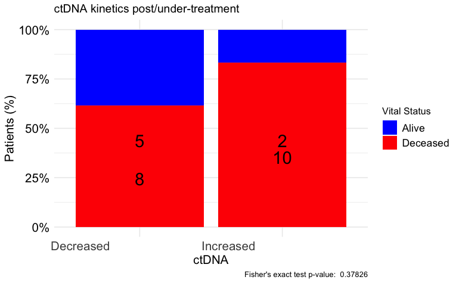

```r
table_df <- as.data.frame(contingency_table)
table_df$Total <- ave(table_df$Freq, table_df$Var1, FUN = sum)
table_df$Percentage <- table_df$Freq / table_df$Total
table_df$MiddlePercentage <- table_df$Percentage / 2
ggplot(table_df, aes(x = Var1, y = Percentage, fill = Var2)) +
  geom_bar(stat = "identity") +
  geom_text(aes(y = MiddlePercentage, label = Freq), position = "stack", color = "black", vjust = 1.5, size = 7) +
  theme_minimal() +
  labs(title = "ctDNA kinetics post/under-treatment",
       x = "ctDNA",
       y = "Patients (%)",
       fill = "Vital Status",
       caption = paste("Fisher's exact test p-value: ", format.pval(fisher_exact_test$p.value))) +
  scale_y_continuous(labels = scales::percent_format()) +
  scale_fill_manual(values = c("Alive" = "blue", "Deceased" = "red")) + # define custom colors
  theme(axis.text.x = element_text(angle = 0, hjust = 1.5, size = 14), # increase x-axis text size
        axis.text.y = element_text(size = 14, color = "black"), # increase y-axis text size
        axis.title.x = element_text(size = 14, color = "black"), # increase x-axis label size
        axis.title.y = element_text(size = 14, color = "black"), # increase y-axis label size
        legend.text = element_text(size = 12, color = "black"))  # increase Progression label size
```

#Association of ctDNA kinetics post/during-ICI with BOR

```r
rm(list=ls())
setwd("~/Downloads")
circ_data <- read.csv("EORTC HNSCC ICI Clinical Data.csv")
circ_data <- circ_data[circ_data$ctDNA.available=="TRUE",]
circ_data <- circ_data[circ_data$ΔctDNA!="",]
circ_datadf <- as.data.frame(circ_data)

circ_data$ΔctDNA <- factor(circ_data$ΔctDNA, levels = c("NEGATIVE", "POSITIVE"), labels = c("Decreased", "Increased"))
circ_data$RESIST <- factor(circ_data$RESIST, levels = c("CR", "PR", "SD", "PD"))
contingency_table <- table(circ_data$ΔctDNA, circ_data$RESIST)
chi_square_test <- chisq.test(contingency_table)
```

```
G2;H2;Warningh in stats::chisq.test(x, y, ...) :
  Chi-squared approximation may be incorrectg
```

```r
print(chi_square_test)
```

```
    Pearson's Chi-squared test

data:  contingency_table
X-squared = 15.385, df = 3, p-value = 0.001516
```

```r
fisher_exact_test <- fisher.test(contingency_table)
print(fisher_exact_test)
```

```
    Fisher's Exact Test for Count Data

data:  contingency_table
p-value = 0.0003154
alternative hypothesis: two.sided
```

```r
print(contingency_table)
```

```
            CR PR SD PD
  Decreased  4  5  3  1
  Increased  0  0  3  9
```

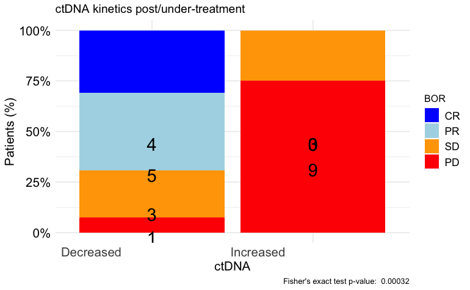

```r
table_df <- as.data.frame(contingency_table)
table_df$Total <- ave(table_df$Freq, table_df$Var1, FUN = sum)
table_df$Percentage <- table_df$Freq / table_df$Total
table_df$MiddlePercentage <- table_df$Percentage / 2
ggplot(table_df, aes(x = Var1, y = Percentage, fill = Var2)) +
  geom_bar(stat = "identity") +
  geom_text(aes(y = MiddlePercentage, label = Freq), position = "stack", color = "black", vjust = 1.5, size = 7) +
  theme_minimal() +
  labs(title = "ctDNA kinetics post/under-treatment",
       x = "ctDNA",
       y = "Patients (%)",
       fill = "BOR",
       caption = paste("Fisher's exact test p-value: ", format.pval(fisher_exact_test$p.value))) +
  scale_y_continuous(labels = scales::percent_format()) +
  scale_fill_manual(values = c("CR" = "blue", "PR" = "lightblue", "SD" = "orange", "PD" = "red")) + # define custom colors
  theme(axis.text.x = element_text(angle = 0, hjust = 1.5, size = 14), # increase x-axis text size
        axis.text.y = element_text(size = 14, color = "black"), # increase y-axis text size
        axis.title.x = element_text(size = 14, color = "black"), # increase x-axis label size
        axis.title.y = element_text(size = 14, color = "black"), # increase y-axis label size
        legend.text = element_text(size = 12, color = "black"))  # increase Progression label size
```

#PFS by ctDNA clearance post/during-ICI

```r
rm(list=ls())
setwd("~/Downloads")
circ_data <- read.csv("EORTC HNSCC ICI Clinical Data.csv")
circ_data <- circ_data[circ_data$ctDNA.available=="TRUE",]
circ_data <- circ_data[circ_data$ctDNA.Base!="",]
circ_data <- circ_data[circ_data$ctDNA.Base=="POSITIVE",]
circ_datadf <- as.data.frame(circ_data)

circ_data$ctDNA.Dynamics <- NA
circ_data <- circ_data %>%
  mutate(ctDNA.Dynamics = case_when(
    ctDNA.Base == "POSITIVE" & ctDNA.postTx == "NEGATIVE" ~ 1,
    ctDNA.Base == "POSITIVE" & ctDNA.postTx == "POSITIVE" ~ 2
  ))

survfit(Surv(time = circ_data$PFS.months, event = circ_data$PFS.Event)~ctDNA.Dynamics, data = circ_data)
```

```
Call: survfit(formula = Surv(time = circ_data$PFS.months, event = circ_data$PFS.Event) ~
    ctDNA.Dynamics, data = circ_data)

                  n events median 0.95LCL 0.95UCL
ctDNA.Dynamics=1  6      2     NA   19.68      NA
ctDNA.Dynamics=2 19     18   3.68    2.37    7.95
```

```r
event_summary <- circ_data %>%
  group_by(ctDNA.Dynamics) %>%
  summarise(
    Total = n(),
    Events = sum(PFS.Event),
    Fraction = Events / n(),
    Percentage = (Events / n()) * 100
  )
print(event_summary)
```

| ctDNA.Dynamics | Total | Events | Fraction | Percentage |
| --- | --- | --- | --- | --- |
| 1 | 6 | 2 | 0.3333333 | 33.33333 |
| 2 | 19 | 18 | 0.9473684 | 94.73684 |

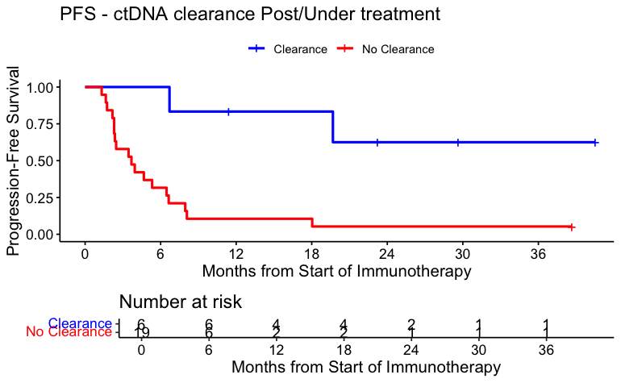

```r
surv_object <-Surv(time = circ_data$PFS.months, event = circ_data$PFS.Event)
KM_curve <- survfit(surv_object ~ ctDNA.Dynamics, data = circ_data,conf.int=0.95,conf.type="log-log")
ggsurvplot(KM_curve, data = circ_data, pval = FALSE, conf.int = FALSE, risk.table = TRUE, break.time.by=6, palette=c("blue","red"), title="PFS - ctDNA clearance Post/Under treatment", ylab= "Progression-Free Survival", xlab="Months from Start of Immunotherapy", legend.labs=c("Clearance", "No Clearance"), legend.title="")
```

```r
summary(KM_curve, times= c(0, 12, 24, 36))
```

```
Call: survfit(formula = surv_object ~ ctDNA.Dynamics, data = circ_data,
    conf.int = 0.95, conf.type = "log-log")

                ctDNA.Dynamics=1
 time n.risk n.event survival std.err lower 95% CI upper 95% CI
    0      6       0    1.000   0.000        1.000        1.000
   12      4       1    0.833   0.152        0.273        0.975
   24      2       1    0.625   0.213        0.142        0.893
   36      1       0    0.625   0.213        0.142        0.893

                ctDNA.Dynamics=2
 time n.risk n.event survival std.err lower 95% CI upper 95% CI
    0     19       0   1.0000  0.0000      1.00000        1.000
   12      2      17   0.1053  0.0704      0.01777        0.284
   24      1       1   0.0526  0.0512      0.00359        0.214
   36      1       0   0.0526  0.0512      0.00359        0.214
```

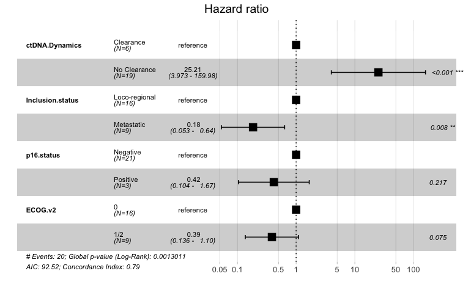

```r
circ_data$ctDNA.Dynamics <- factor(circ_data$ctDNA.Dynamics, levels=c("1","2"), labels = c("Clearance", "No Clearance"))
circ_data$Inclusion.status <- factor(circ_data$Inclusion.status, levels = c("Loco-regional", "Metastatic"))
circ_data$p16.status <- factor(circ_data$p16.status, levels = c("Negative", "Positive"))
circ_data$ECOG.v2 <- factor(circ_data$ECOG.v2, levels = c("0", "1/2"))
cox_fit <- coxph(surv_object ~ ctDNA.Dynamics + Inclusion.status + p16.status + ECOG.v2, data=circ_data)
ggforest(cox_fit,data = circ_data)
```

```r
summary(cox_fit)
```

```
Call:
coxph(formula = surv_object ~ ctDNA.Dynamics + Inclusion.status +
    p16.status + ECOG.v2, data = circ_data)

  n= 24, number of events= 20
   (1 observation deleted due to missingness)

                              coef exp(coef) se(coef)      z Pr(>|z|)
ctDNA.DynamicsNo Clearance  3.2273   25.2118   0.9427  3.423 0.000618 ***
Inclusion.statusMetastatic -1.6899    0.1845   0.6328 -2.671 0.007568 **
p16.statusPositive         -0.8753    0.4167   0.7088 -1.235 0.216873
ECOG.v21/2                 -0.9498    0.3868   0.5328 -1.783 0.074662 .
---
Signif. codes:  0 ‘***’ 0.001 ‘**’ 0.01 ‘*’ 0.05 ‘.’ 0.1 ‘ ’ 1

                           exp(coef) exp(-coef) lower .95 upper .95
ctDNA.DynamicsNo Clearance   25.2118    0.03966   3.97331  159.9761
Inclusion.statusMetastatic    0.1845    5.41913   0.05339    0.6378
p16.statusPositive            0.4167    2.39956   0.10388    1.6719
ECOG.v21/2                    0.3868    2.58524   0.13613    1.0992

Concordance= 0.787  (se = 0.036 )
Likelihood ratio test= 17.88  on 4 df,   p=0.001
Wald test            = 13.08  on 4 df,   p=0.01
Score (logrank) test = 15.23  on 4 df,   p=0.004
```

```r
cox_fit_summary <- summary(cox_fit)

circ_data$PFS.Event <- factor(circ_data$PFS.Event, levels = c("FALSE", "TRUE"), labels = c("No Progression", "Progression"))
contingency_table <- table(circ_data$ctDNA.Dynamics, circ_data$PFS.Event)
chi_square_test <- chisq.test(contingency_table)
```

```
G2;H2;Warningh in stats::chisq.test(x, y, ...) :
  Chi-squared approximation may be incorrectg
```

```r
print(chi_square_test)
```

```
    Pearson's Chi-squared test with Yates' continuity correction

data:  contingency_table
X-squared = 7.2505, df = 1, p-value = 0.007088
```

```r
fisher_exact_test <- fisher.test(contingency_table)
print(fisher_exact_test)
```

```
    Fisher's Exact Test for Count Data

data:  contingency_table
p-value = 0.005477
alternative hypothesis: true odds ratio is not equal to 1
95 percent confidence interval:
    1.796359 1833.444857
sample estimates:
odds ratio
  27.59073
```

```r
print(contingency_table)
```

```
               No Progression Progression
  Clearance                 4           2
  No Clearance              1          18
```

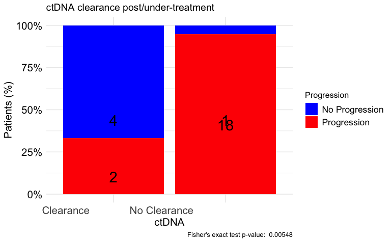

```r
table_df <- as.data.frame(contingency_table)
table_df$Total <- ave(table_df$Freq, table_df$Var1, FUN = sum)
table_df$Percentage <- table_df$Freq / table_df$Total
table_df$MiddlePercentage <- table_df$Percentage / 2
ggplot(table_df, aes(x = Var1, y = Percentage, fill = Var2)) +
  geom_bar(stat = "identity") +
  geom_text(aes(y = MiddlePercentage, label = Freq), position = "stack", color = "black", vjust = 1.5, size = 7) +
  theme_minimal() +
  labs(title = "ctDNA clearance post/under-treatment",
       x = "ctDNA",
       y = "Patients (%)",
       fill = "Progression",
       caption = paste("Fisher's exact test p-value: ", format.pval(fisher_exact_test$p.value))) +
  scale_y_continuous(labels = scales::percent_format()) +
  scale_fill_manual(values = c("No Progression" = "blue", "Progression" = "red")) + # define custom colors
  theme(axis.text.x = element_text(angle = 0, hjust = 1.5, size = 14), # increase x-axis text size
        axis.text.y = element_text(size = 14, color = "black"), # increase y-axis text size
        axis.title.x = element_text(size = 14, color = "black"), # increase x-axis label size
        axis.title.y = element_text(size = 14, color = "black"), # increase y-axis label size
        legend.text = element_text(size = 12, color = "black"))  # increase Progression label size
```

#OS by ctDNA clearance post/during-ICI

```r
rm(list=ls())
setwd("~/Downloads")
circ_data <- read.csv("EORTC HNSCC ICI Clinical Data.csv")
circ_data <- circ_data[circ_data$ctDNA.available=="TRUE",]
circ_data <- circ_data[circ_data$ctDNA.Base!="",]
circ_data <- circ_data[circ_data$ctDNA.Base=="POSITIVE",]
circ_datadf <- as.data.frame(circ_data)

circ_data$ctDNA.Dynamics <- NA
circ_data <- circ_data %>%
  mutate(ctDNA.Dynamics = case_when(
    ctDNA.Base == "POSITIVE" & ctDNA.postTx == "NEGATIVE" ~ 1,
    ctDNA.Base == "POSITIVE" & ctDNA.postTx == "POSITIVE" ~ 2
  ))

survfit(Surv(time = circ_data$OS.months, event = circ_data$OS.Event)~ctDNA.Dynamics, data = circ_data)
```

```
Call: survfit(formula = Surv(time = circ_data$OS.months, event = circ_data$OS.Event) ~
    ctDNA.Dynamics, data = circ_data)

                  n events median 0.95LCL 0.95UCL
ctDNA.Dynamics=1  6      2     NA   20.50      NA
ctDNA.Dynamics=2 19     16   9.82    7.75    26.7
```

```r
event_summary <- circ_data %>%
  group_by(ctDNA.Dynamics) %>%
  summarise(
    Total = n(),
    Events = sum(OS.Event),
    Fraction = Events / n(),
    Percentage = (Events / n()) * 100
  )
print(event_summary)
```

| ctDNA.Dynamics | Total | Events | Fraction | Percentage |
| --- | --- | --- | --- | --- |
| 1 | 6 | 2 | 0.3333333 | 33.33333 |
| 2 | 19 | 16 | 0.8421053 | 84.21053 |

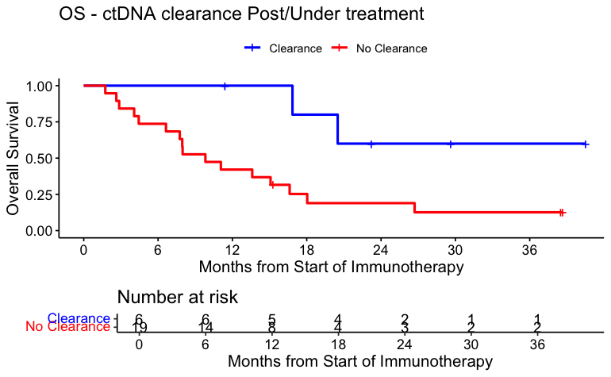

```r
surv_object <-Surv(time = circ_data$OS.months, event = circ_data$OS.Event)
KM_curve <- survfit(surv_object ~ ctDNA.Dynamics, data = circ_data,conf.int=0.95,conf.type="log-log")
ggsurvplot(KM_curve, data = circ_data, pval = FALSE, conf.int = FALSE, risk.table = TRUE, break.time.by=6, palette=c("blue","red"), title="OS - ctDNA clearance Post/Under treatment", ylab= "Overall Survival", xlab="Months from Start of Immunotherapy", legend.labs=c("Clearance", "No Clearance"), legend.title="")
```

```r
summary(KM_curve, times= c(0, 12, 24, 36))
```

```
Call: survfit(formula = surv_object ~ ctDNA.Dynamics, data = circ_data,
    conf.int = 0.95, conf.type = "log-log")

                ctDNA.Dynamics=1
 time n.risk n.event survival std.err lower 95% CI upper 95% CI
    0      6       0      1.0   0.000        1.000        1.000
   12      5       0      1.0   0.000           NA           NA
   24      2       2      0.6   0.219        0.126        0.882
   36      1       0      0.6   0.219        0.126        0.882

                ctDNA.Dynamics=2
 time n.risk n.event survival std.err lower 95% CI upper 95% CI
    0     19       0    1.000  0.0000       1.0000        1.000
   12      8      11    0.421  0.1133       0.2037        0.625
   24      3       4    0.189  0.0942       0.0503        0.396
   36      2       1    0.126  0.0813       0.0222        0.325
```

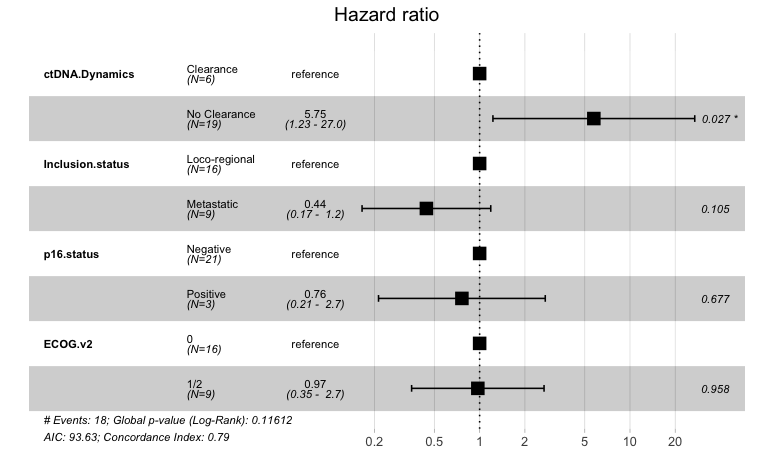

```r
circ_data$ctDNA.Dynamics <- factor(circ_data$ctDNA.Dynamics, levels=c("1","2"), labels = c("Clearance", "No Clearance"))
circ_data$Inclusion.status <- factor(circ_data$Inclusion.status, levels = c("Loco-regional", "Metastatic"))
circ_data$p16.status <- factor(circ_data$p16.status, levels = c("Negative", "Positive"))
circ_data$ECOG.v2 <- factor(circ_data$ECOG.v2, levels = c("0", "1/2"))
cox_fit <- coxph(surv_object ~ ctDNA.Dynamics + Inclusion.status + p16.status + ECOG.v2, data=circ_data)
ggforest(cox_fit,data = circ_data)
```

```r
summary(cox_fit)
```

```
Call:
coxph(formula = surv_object ~ ctDNA.Dynamics + Inclusion.status +
    p16.status + ECOG.v2, data = circ_data)

  n= 24, number of events= 18
   (1 observation deleted due to missingness)

                              coef exp(coef) se(coef)      z Pr(>|z|)
ctDNA.DynamicsNo Clearance  1.7490    5.7485   0.7885  2.218   0.0265 *
Inclusion.statusMetastatic -0.8151    0.4426   0.5028 -1.621   0.1050
p16.statusPositive         -0.2716    0.7622   0.6514 -0.417   0.6767
ECOG.v21/2                 -0.0275    0.9729   0.5174 -0.053   0.9576
---
Signif. codes:  0 ‘***’ 0.001 ‘**’ 0.01 ‘*’ 0.05 ‘.’ 0.1 ‘ ’ 1

                           exp(coef) exp(-coef) lower .95 upper .95
ctDNA.DynamicsNo Clearance    5.7486      0.174    1.2258    26.958
Inclusion.statusMetastatic    0.4426      2.259    0.1652     1.186
p16.statusPositive            0.7622      1.312    0.2126     2.732
ECOG.v21/2                    0.9729      1.028    0.3529     2.682

Concordance= 0.788  (se = 0.061 )
Likelihood ratio test= 7.4  on 4 df,   p=0.1
Wald test            = 6.28  on 4 df,   p=0.2
Score (logrank) test = 6.92  on 4 df,   p=0.1
```

```r
cox_fit_summary <- summary(cox_fit)

circ_data$OS.Event <- factor(circ_data$OS.Event, levels = c("FALSE", "TRUE"), labels = c("Alive", "Deceased"))
contingency_table <- table(circ_data$ctDNA.Dynamics, circ_data$OS.Event)
chi_square_test <- chisq.test(contingency_table)
```

```
G2;H2;Warningh in stats::chisq.test(x, y, ...) :
  Chi-squared approximation may be incorrectg
```

```r
print(chi_square_test)
```

```
    Pearson's Chi-squared test with Yates' continuity correction

data:  contingency_table
X-squared = 3.6032, df = 1, p-value = 0.05767
```

```r
fisher_exact_test <- fisher.test(contingency_table)
print(fisher_exact_test)
```

```
    Fisher's Exact Test for Count Data

data:  contingency_table
p-value = 0.03241
alternative hypothesis: true odds ratio is not equal to 1
95 percent confidence interval:
   0.8988842 150.9697807
sample estimates:
odds ratio
   9.34674
```

```r
print(contingency_table)
```

```
               Alive Deceased
  Clearance        4        2
  No Clearance     3       16
```

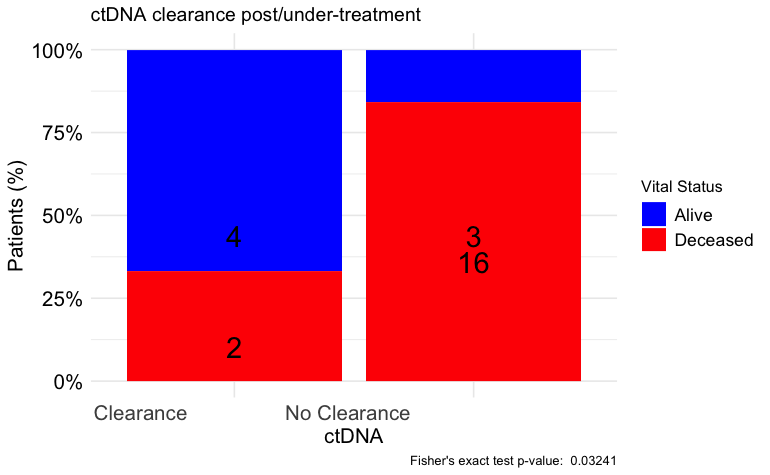

```r
table_df <- as.data.frame(contingency_table)
table_df$Total <- ave(table_df$Freq, table_df$Var1, FUN = sum)
table_df$Percentage <- table_df$Freq / table_df$Total
table_df$MiddlePercentage <- table_df$Percentage / 2
ggplot(table_df, aes(x = Var1, y = Percentage, fill = Var2)) +
  geom_bar(stat = "identity") +
  geom_text(aes(y = MiddlePercentage, label = Freq), position = "stack", color = "black", vjust = 1.5, size = 7) +
  theme_minimal() +
  labs(title = "ctDNA clearance post/under-treatment",
       x = "ctDNA",
       y = "Patients (%)",
       fill = "Vital Status",
       caption = paste("Fisher's exact test p-value: ", format.pval(fisher_exact_test$p.value))) +
  scale_y_continuous(labels = scales::percent_format()) +
  scale_fill_manual(values = c("Alive" = "blue", "Deceased" = "red")) + # define custom colors
  theme(axis.text.x = element_text(angle = 0, hjust = 1.5, size = 14), # increase x-axis text size
        axis.text.y = element_text(size = 14, color = "black"), # increase y-axis text size
        axis.title.x = element_text(size = 14, color = "black"), # increase x-axis label size
        axis.title.y = element_text(size = 14, color = "black"), # increase y-axis label size
        legend.text = element_text(size = 12, color = "black"))  # increase Progression label size
```

#Association of ctDNA clearance post/during-ICI with BOR

```r
rm(list=ls())
setwd("~/Downloads")
circ_data <- read.csv("EORTC HNSCC ICI Clinical Data.csv")
circ_data <- circ_data[circ_data$ctDNA.available=="TRUE",]
circ_data <- circ_data[circ_data$ctDNA.Base!="",]
circ_data <- circ_data[circ_data$ctDNA.Base=="POSITIVE",]
circ_datadf <- as.data.frame(circ_data)

circ_data$ctDNA.Dynamics <- NA
circ_data <- circ_data %>%
  mutate(ctDNA.Dynamics = case_when(
    ctDNA.Base == "POSITIVE" & ctDNA.postTx == "NEGATIVE" ~ 1,
    ctDNA.Base == "POSITIVE" & ctDNA.postTx == "POSITIVE" ~ 2
  ))

circ_data$ctDNA.Dynamics <- factor(circ_data$ctDNA.Dynamics, levels=c("1","2"), labels = c("Clearance", "No Clearance"))
circ_data$RESIST <- factor(circ_data$RESIST, levels = c("CR", "PR", "SD", "PD"))
contingency_table <- table(circ_data$ctDNA.Dynamics, circ_data$RESIST)
chi_square_test <- chisq.test(contingency_table)
```

```
G2;H2;Warningh in stats::chisq.test(x, y, ...) :
  Chi-squared approximation may be incorrectg
```

```r
print(chi_square_test)
```

```
    Pearson's Chi-squared test

data:  contingency_table
X-squared = 14.309, df = 3, p-value = 0.002513
```

```r
fisher_exact_test <- fisher.test(contingency_table)
print(fisher_exact_test)
```

```
    Fisher's Exact Test for Count Data

data:  contingency_table
p-value = 0.001129
alternative hypothesis: two.sided
```

```r
print(contingency_table)
```

```
               CR PR SD PD
  Clearance     3  3  0  0
  No Clearance  1  2  6 10
```

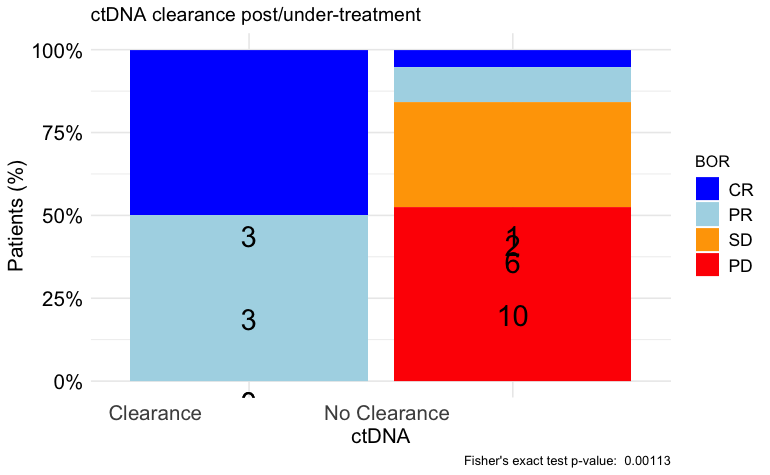

```r
table_df <- as.data.frame(contingency_table)
table_df$Total <- ave(table_df$Freq, table_df$Var1, FUN = sum)
table_df$Percentage <- table_df$Freq / table_df$Total
table_df$MiddlePercentage <- table_df$Percentage / 2
ggplot(table_df, aes(x = Var1, y = Percentage, fill = Var2)) +
  geom_bar(stat = "identity") +
  geom_text(aes(y = MiddlePercentage, label = Freq), position = "stack", color = "black", vjust = 1.5, size = 7) +
  theme_minimal() +
  labs(title = "ctDNA clearance post/under-treatment",
       x = "ctDNA",
       y = "Patients (%)",
       fill = "BOR",
       caption = paste("Fisher's exact test p-value: ", format.pval(fisher_exact_test$p.value))) +
  scale_y_continuous(labels = scales::percent_format()) +
  scale_fill_manual(values = c("CR" = "blue", "PR" = "lightblue", "SD" = "orange", "PD" = "red")) + # define custom colors
  theme(axis.text.x = element_text(angle = 0, hjust = 1.5, size = 14), # increase x-axis text size
        axis.text.y = element_text(size = 14, color = "black"), # increase y-axis text size
        axis.title.x = element_text(size = 14, color = "black"), # increase x-axis label size
        axis.title.y = element_text(size = 14, color = "black"), # increase y-axis label size
        legend.text = element_text(size = 12, color = "black"))  # increase Progression label size
```

#Multivariate cox regression for PFS - ctDNA clearance

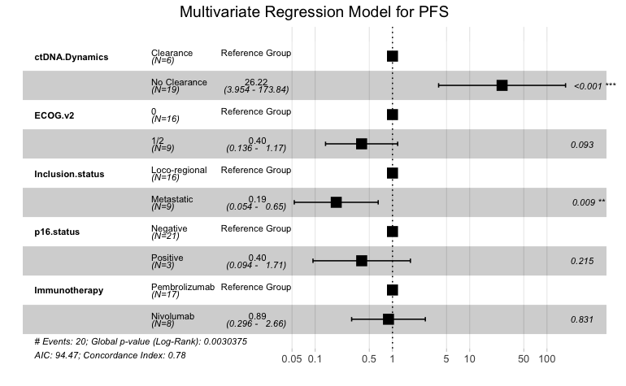

```r
rm(list=ls())
setwd("~/Downloads")
circ_data <- read.csv("EORTC HNSCC ICI Clinical Data.csv")
circ_data <- circ_data[circ_data$ctDNA.available=="TRUE",]
circ_data <- circ_data[circ_data$ctDNA.Base!="",]
circ_data <- circ_data[circ_data$ctDNA.Base=="POSITIVE",]
circ_datadf <- as.data.frame(circ_data)

circ_data$ctDNA.Dynamics <- NA
circ_data <- circ_data %>%
  mutate(ctDNA.Dynamics = case_when(
    ctDNA.Base == "POSITIVE" & ctDNA.postTx == "NEGATIVE" ~ 1,
    ctDNA.Base == "POSITIVE" & ctDNA.postTx == "POSITIVE" ~ 2
  ))

circ_data$ctDNA.Dynamics <- factor(circ_data$ctDNA.Dynamics, levels=c("1","2"), labels = c("Clearance", "No Clearance"))
circ_data$Inclusion.status <- factor(circ_data$Inclusion.status, levels = c("Loco-regional", "Metastatic"))
circ_data$p16.status <- factor(circ_data$p16.status, levels = c("Negative", "Positive"))
circ_data$CPS.Scorev2 <- factor(circ_data$CPS.Scorev2, levels = c("≥1", "<1"))
circ_data$ECOG.v2 <- factor(circ_data$ECOG.v2, levels = c("0", "1/2"))
circ_data$Immunotherapy <- factor(circ_data$Immunotherapy, levels = c("Pembrolizumab", "Nivolumab"))
surv_object <- Surv(time = circ_data$PFS.months, event = circ_data$PFS.Event)
cox_fit <- coxph(surv_object ~ ctDNA.Dynamics + ECOG.v2 + Inclusion.status + p16.status + Immunotherapy, data=circ_data)
ggforest(cox_fit, data = circ_data, main = "Multivariate Regression Model for PFS", refLabel = "Reference Group")
```

```r
test.ph <- cox.zph(cox_fit)
```

#Multivariate cox regression for PFS - ctDNA kinetics

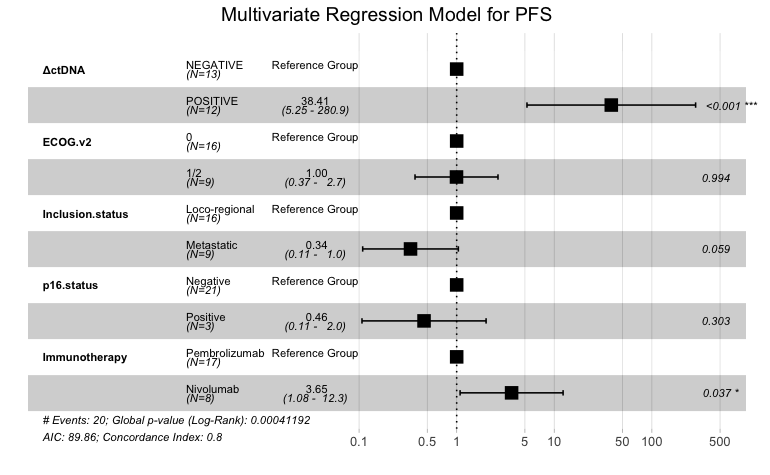

```r
rm(list=ls())
setwd("~/Downloads")
circ_data <- read.csv("EORTC HNSCC ICI Clinical Data.csv")
circ_data <- circ_data[circ_data$ctDNA.available=="TRUE",]
circ_data <- circ_data[circ_data$ΔctDNA!="",]
circ_datadf <- as.data.frame(circ_data)

circ_data$ΔctDNA <- factor(circ_data$ΔctDNA, levels=c("NEGATIVE","POSITIVE"))
circ_data$Inclusion.status <- factor(circ_data$Inclusion.status, levels = c("Loco-regional", "Metastatic"))
circ_data$p16.status <- factor(circ_data$p16.status, levels = c("Negative", "Positive"))
circ_data$CPS.Scorev2 <- factor(circ_data$CPS.Scorev2, levels = c("≥1", "<1"))
circ_data$ECOG.v2 <- factor(circ_data$ECOG.v2, levels = c("0", "1/2"))
circ_data$Immunotherapy <- factor(circ_data$Immunotherapy, levels = c("Pembrolizumab", "Nivolumab"))
surv_object <- Surv(time = circ_data$PFS.months, event = circ_data$PFS.Event)
cox_fit <- coxph(surv_object ~ ΔctDNA + ECOG.v2 + Inclusion.status + p16.status + Immunotherapy, data=circ_data)
ggforest(cox_fit, data = circ_data, main = "Multivariate Regression Model for PFS", refLabel = "Reference Group")
```

```r
test.ph <- cox.zph(cox_fit)
```

#Univariate PFS cox regression for variables included in MVA

```r
rm(list=ls())
setwd("~/Downloads")
circ_data <- read.csv("EORTC HNSCC ICI Clinical Data.csv")
circ_data <- circ_data[circ_data$ctDNA.available=="TRUE",]
circ_data <- circ_data[circ_data$ctDNA.Base!="",]
circ_data <- circ_data[circ_data$ctDNA.Base=="POSITIVE",]

circ_data$ctDNA.Dynamics <- NA
circ_data <- circ_data %>%
  mutate(ctDNA.Dynamics = case_when(
    ctDNA.Base == "POSITIVE" & ctDNA.postTx == "NEGATIVE" ~ 1,
    ctDNA.Base == "POSITIVE" & ctDNA.postTx == "POSITIVE" ~ 2
  ))
surv_object <-Surv(time = circ_data$PFS.months, event = circ_data$PFS.Event)
circ_data$ctDNA.Dynamics <- factor(circ_data$ctDNA.Dynamics, levels=c("1","2"), labels = c("Clearance", "No Clearance")) #univariate for ctDNA clearance post-treatment
cox_fit <- coxph(surv_object ~ ctDNA.Dynamics, data=circ_data)
summary(cox_fit)
```

```
Call:
coxph(formula = surv_object ~ ctDNA.Dynamics, data = circ_data)

  n= 25, number of events= 20

                            coef exp(coef) se(coef)     z Pr(>|z|)
ctDNA.DynamicsNo Clearance 2.085     8.048    0.767 2.719  0.00655 **
---
Signif. codes:  0 ‘***’ 0.001 ‘**’ 0.01 ‘*’ 0.05 ‘.’ 0.1 ‘ ’ 1

                           exp(coef) exp(-coef) lower .95 upper .95
ctDNA.DynamicsNo Clearance     8.048     0.1243      1.79     36.19

Concordance= 0.672  (se = 0.049 )
Likelihood ratio test= 11.61  on 1 df,   p=7e-04
Wald test            = 7.39  on 1 df,   p=0.007
Score (logrank) test = 9.78  on 1 df,   p=0.002
```

```r
cox_fit_summary <- summary(cox_fit)

#Extract values for HR, 95% CI, and p-value
HR <- cox_fit_summary$coefficients[2]
lower_CI <- cox_fit_summary$conf.int[3]
upper_CI <- cox_fit_summary$conf.int[4]
p_value <- cox_fit_summary$coefficients[5]
label_text <- paste0("HR = ", round(HR, 2), " (", round(lower_CI, 2), "-", round(upper_CI, 2), "); p = ", round(p_value, 3))
print(label_text)
```

```
[1] "HR = 8.05 (1.79-36.19); p = 0.007"
```

```r
rm(list=ls())
setwd("~/Downloads")
circ_data <- read.csv("EORTC HNSCC ICI Clinical Data.csv")
circ_data <- circ_data[circ_data$ctDNA.available=="TRUE",]
circ_data <- circ_data[circ_data$ΔctDNA!="",]
surv_object <-Surv(time = circ_data$PFS.months, event = circ_data$PFS.Event)
circ_data$ΔctDNA <- factor(circ_data$ΔctDNA, levels=c("NEGATIVE","POSITIVE"))
cox_fit <- coxph(surv_object ~ ΔctDNA, data=circ_data) #univariate for ΔctDNA
summary(cox_fit)
```

```
Call:
coxph(formula = surv_object ~ ΔctDNA, data = circ_data)

  n= 25, number of events= 20

                 coef exp(coef) se(coef)    z Pr(>|z|)
ΔctDNAPOSITIVE  2.716    15.112    0.794 3.42 0.000626 ***
---
Signif. codes:  0 ‘***’ 0.001 ‘**’ 0.01 ‘*’ 0.05 ‘.’ 0.1 ‘ ’ 1

               exp(coef) exp(-coef) lower .95 upper .95
ΔctDNAPOSITIVE     15.11    0.06617     3.188     71.64

Concordance= 0.716  (se = 0.044 )
Likelihood ratio test= 17.9  on 1 df,   p=2e-05
Wald test            = 11.7  on 1 df,   p=6e-04
Score (logrank) test = 18.33  on 1 df,   p=2e-05
```

```r
cox_fit_summary <- summary(cox_fit)

#Extract values for HR, 95% CI, and p-value
HR <- cox_fit_summary$coefficients[2]
lower_CI <- cox_fit_summary$conf.int[3]
upper_CI <- cox_fit_summary$conf.int[4]
p_value <- cox_fit_summary$coefficients[5]
label_text <- paste0("HR = ", round(HR, 2), " (", round(lower_CI, 2), "-", round(upper_CI, 2), "); p = ", round(p_value, 3))
print(label_text)
```

```
[1] "HR = 15.11 (3.19-71.64); p = 0.001"
```

```r
rm(list=ls())
setwd("~/Downloads")
circ_data <- read.csv("EORTC HNSCC ICI Clinical Data.csv")
circ_data <- circ_data[circ_data$ctDNA.available=="TRUE",]
circ_data <- circ_data[circ_data$ctDNA.Base!="",]
circ_data <- circ_data[circ_data$ctDNA.Base=="POSITIVE",]
surv_object <-Surv(time = circ_data$PFS.months, event = circ_data$PFS.Event)
circ_data$ECOG.v2 <- factor(circ_data$ECOG.v2, levels = c("0", "1/2"))
cox_fit <- coxph(surv_object ~ ECOG.v2, data=circ_data) #univariate for ECOG
summary(cox_fit)
```

```
Call:
coxph(formula = surv_object ~ ECOG.v2, data = circ_data)

  n= 25, number of events= 20

              coef exp(coef) se(coef)     z Pr(>|z|)
ECOG.v21/2 0.05209   1.05347  0.47029 0.111    0.912

           exp(coef) exp(-coef) lower .95 upper .95
ECOG.v21/2     1.053     0.9492    0.4191     2.648

Concordance= 0.521  (se = 0.062 )
Likelihood ratio test= 0.01  on 1 df,   p=0.9
Wald test            = 0.01  on 1 df,   p=0.9
Score (logrank) test = 0.01  on 1 df,   p=0.9
```

```r
cox_fit_summary <- summary(cox_fit)

#Extract values for HR, 95% CI, and p-value
HR <- cox_fit_summary$coefficients[2]
lower_CI <- cox_fit_summary$conf.int[3]
upper_CI <- cox_fit_summary$conf.int[4]
p_value <- cox_fit_summary$coefficients[5]
label_text <- paste0("HR = ", round(HR, 2), " (", round(lower_CI, 2), "-", round(upper_CI, 2), "); p = ", round(p_value, 3))
print(label_text)
```

```
[1] "HR = 1.05 (0.42-2.65); p = 0.912"
```

```r
rm(list=ls())
setwd("~/Downloads")
circ_data <- read.csv("EORTC HNSCC ICI Clinical Data.csv")
circ_data <- circ_data[circ_data$ctDNA.available=="TRUE",]
circ_data <- circ_data[circ_data$ctDNA.Base!="",]
circ_data <- circ_data[circ_data$ctDNA.Base=="POSITIVE",]
surv_object <-Surv(time = circ_data$PFS.months, event = circ_data$PFS.Event)
circ_data$Inclusion.status <- factor(circ_data$Inclusion.status, levels = c("Loco-regional", "Metastatic")) #univariate for Stage/disease status
cox_fit <- coxph(surv_object ~ Inclusion.status, data=circ_data)
summary(cox_fit)
```

```
Call:
coxph(formula = surv_object ~ Inclusion.status, data = circ_data)

  n= 25, number of events= 20

                              coef exp(coef) se(coef)      z Pr(>|z|)
Inclusion.statusMetastatic -0.1110    0.8949   0.4582 -0.242    0.809

                           exp(coef) exp(-coef) lower .95 upper .95
Inclusion.statusMetastatic    0.8949      1.117    0.3646     2.197

Concordance= 0.556  (se = 0.056 )
Likelihood ratio test= 0.06  on 1 df,   p=0.8
Wald test            = 0.06  on 1 df,   p=0.8
Score (logrank) test = 0.06  on 1 df,   p=0.8
```

```r
cox_fit_summary <- summary(cox_fit)

#Extract values for HR, 95% CI, and p-value
HR <- cox_fit_summary$coefficients[2]
lower_CI <- cox_fit_summary$conf.int[3]
upper_CI <- cox_fit_summary$conf.int[4]
p_value <- cox_fit_summary$coefficients[5]
label_text <- paste0("HR = ", round(HR, 2), " (", round(lower_CI, 2), "-", round(upper_CI, 2), "); p = ", round(p_value, 3))
print(label_text)
```

```
[1] "HR = 0.89 (0.36-2.2); p = 0.809"
```

```r
rm(list=ls())
setwd("~/Downloads")
circ_data <- read.csv("EORTC HNSCC ICI Clinical Data.csv")
circ_data <- circ_data[circ_data$ctDNA.available=="TRUE",]
circ_data <- circ_data[circ_data$ctDNA.Base!="",]
circ_data <- circ_data[circ_data$ctDNA.Base=="POSITIVE",]
surv_object <-Surv(time = circ_data$PFS.months, event = circ_data$PFS.Event)
circ_data$p16.status <- factor(circ_data$p16.status, levels = c("Negative", "Positive")) #univariate for p16 status
cox_fit <- coxph(surv_object ~ p16.status, data=circ_data)
summary(cox_fit)
```

```
Call:
coxph(formula = surv_object ~ p16.status, data = circ_data)

  n= 24, number of events= 20
   (1 observation deleted due to missingness)

                     coef exp(coef) se(coef)    z Pr(>|z|)
p16.statusPositive 0.2431    1.2752   0.6402 0.38    0.704

                   exp(coef) exp(-coef) lower .95 upper .95
p16.statusPositive     1.275     0.7842    0.3636     4.472

Concordance= 0.491  (se = 0.027 )
Likelihood ratio test= 0.14  on 1 df,   p=0.7
Wald test            = 0.14  on 1 df,   p=0.7
Score (logrank) test = 0.14  on 1 df,   p=0.7
```

```r
cox_fit_summary <- summary(cox_fit)

#Extract values for HR, 95% CI, and p-value
HR <- cox_fit_summary$coefficients[2]
lower_CI <- cox_fit_summary$conf.int[3]
upper_CI <- cox_fit_summary$conf.int[4]
p_value <- cox_fit_summary$coefficients[5]
label_text <- paste0("HR = ", round(HR, 2), " (", round(lower_CI, 2), "-", round(upper_CI, 2), "); p = ", round(p_value, 3))
print(label_text)
```

```
[1] "HR = 1.28 (0.36-4.47); p = 0.704"
```

```r
rm(list=ls())
setwd("~/Downloads")
circ_data <- read.csv("EORTC HNSCC ICI Clinical Data.csv")
circ_data <- circ_data[circ_data$ctDNA.available=="TRUE",]
circ_data <- circ_data[circ_data$ctDNA.Base!="",]
circ_data <- circ_data[circ_data$ctDNA.Base=="POSITIVE",]
surv_object <-Surv(time = circ_data$PFS.months, event = circ_data$PFS.Event)
circ_data$Immunotherapy <- factor(circ_data$Immunotherapy, levels = c("Pembrolizumab", "Nivolumab"))
cox_fit <- coxph(surv_object ~ Immunotherapy, data=circ_data) #univariate for Immunotherapy regimen
summary(cox_fit)
```

```
Call:
coxph(formula = surv_object ~ Immunotherapy, data = circ_data)

  n= 25, number of events= 20

                         coef exp(coef) se(coef)     z Pr(>|z|)
ImmunotherapyNivolumab 0.2901    1.3365   0.4709 0.616    0.538

                       exp(coef) exp(-coef) lower .95 upper .95
ImmunotherapyNivolumab     1.337     0.7482     0.531     3.364

Concordance= 0.54  (se = 0.061 )
Likelihood ratio test= 0.37  on 1 df,   p=0.5
Wald test            = 0.38  on 1 df,   p=0.5
Score (logrank) test = 0.38  on 1 df,   p=0.5
```

```r
cox_fit_summary <- summary(cox_fit)

#Extract values for HR, 95% CI, and p-value
HR <- cox_fit_summary$coefficients[2]
lower_CI <- cox_fit_summary$conf.int[3]
upper_CI <- cox_fit_summary$conf.int[4]
p_value <- cox_fit_summary$coefficients[5]
label_text <- paste0("HR = ", round(HR, 2), " (", round(lower_CI, 2), "-", round(upper_CI, 2), "); p = ", round(p_value, 3))
print(label_text)
```

```
[1] "HR = 1.34 (0.53-3.36); p = 0.538"
```

#Multivariate cox regression for OS - ctDNA clearance

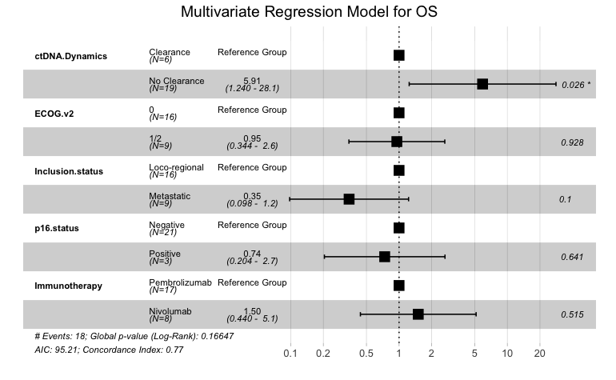

```r
rm(list=ls())
setwd("~/Downloads")
circ_data <- read.csv("EORTC HNSCC ICI Clinical Data.csv")
circ_data <- circ_data[circ_data$ctDNA.available=="TRUE",]
circ_data <- circ_data[circ_data$ctDNA.Base!="",]
circ_data <- circ_data[circ_data$ctDNA.Base=="POSITIVE",]
circ_datadf <- as.data.frame(circ_data)

circ_data$ctDNA.Dynamics <- NA
circ_data <- circ_data %>%
  mutate(ctDNA.Dynamics = case_when(
    ctDNA.Base == "POSITIVE" & ctDNA.postTx == "NEGATIVE" ~ 1,
    ctDNA.Base == "POSITIVE" & ctDNA.postTx == "POSITIVE" ~ 2
  ))

circ_data$ctDNA.Dynamics <- factor(circ_data$ctDNA.Dynamics, levels=c("1","2"), labels = c("Clearance", "No Clearance"))
circ_data$Inclusion.status <- factor(circ_data$Inclusion.status, levels = c("Loco-regional", "Metastatic"))
circ_data$p16.status <- factor(circ_data$p16.status, levels = c("Negative", "Positive"))
circ_data$CPS.Scorev2 <- factor(circ_data$CPS.Scorev2, levels = c("≥1", "<1"))
circ_data$ECOG.v2 <- factor(circ_data$ECOG.v2, levels = c("0", "1/2"))
circ_data$Immunotherapy <- factor(circ_data$Immunotherapy, levels = c("Pembrolizumab", "Nivolumab"))
surv_object <- Surv(time = circ_data$OS.months, event = circ_data$OS.Event)
cox_fit <- coxph(surv_object ~ ctDNA.Dynamics + ECOG.v2 + Inclusion.status + p16.status + Immunotherapy, data=circ_data)
ggforest(cox_fit, data = circ_data, main = "Multivariate Regression Model for OS", refLabel = "Reference Group")
```

```r
test.ph <- cox.zph(cox_fit)
```

#Multivariate cox regression for OS - ctDNA kinetics

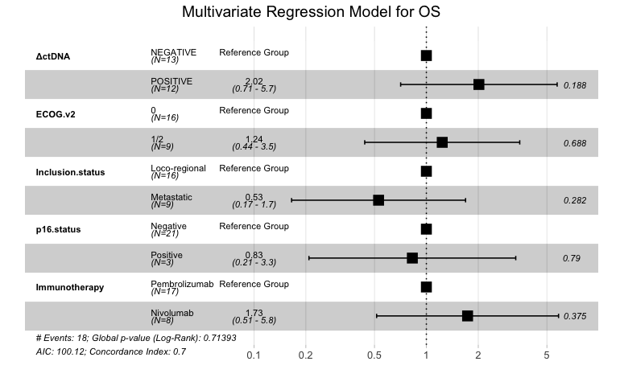

```r
rm(list=ls())
setwd("~/Downloads")
circ_data <- read.csv("EORTC HNSCC ICI Clinical Data.csv")
circ_data <- circ_data[circ_data$ctDNA.available=="TRUE",]
circ_data <- circ_data[circ_data$ΔctDNA!="",]
circ_datadf <- as.data.frame(circ_data)

circ_data$ΔctDNA <- factor(circ_data$ΔctDNA, levels=c("NEGATIVE","POSITIVE"))
circ_data$Inclusion.status <- factor(circ_data$Inclusion.status, levels = c("Loco-regional", "Metastatic"))
circ_data$p16.status <- factor(circ_data$p16.status, levels = c("Negative", "Positive"))
circ_data$CPS.Scorev2 <- factor(circ_data$CPS.Scorev2, levels = c("≥1", "<1"))
circ_data$ECOG.v2 <- factor(circ_data$ECOG.v2, levels = c("0", "1/2"))
circ_data$Immunotherapy <- factor(circ_data$Immunotherapy, levels = c("Pembrolizumab", "Nivolumab"))
surv_object <- Surv(time = circ_data$OS.months, event = circ_data$OS.Event)
cox_fit <- coxph(surv_object ~ ΔctDNA + ECOG.v2 + Inclusion.status + p16.status + Immunotherapy, data=circ_data)
ggforest(cox_fit, data = circ_data, main = "Multivariate Regression Model for OS", refLabel = "Reference Group")
```

```r
test.ph <- cox.zph(cox_fit)
```

#Univariate OS cox regression for variables included in MVA

```r
rm(list=ls())
setwd("~/Downloads")
circ_data <- read.csv("EORTC HNSCC ICI Clinical Data.csv")
circ_data <- circ_data[circ_data$ctDNA.available=="TRUE",]
circ_data <- circ_data[circ_data$ctDNA.Base!="",]
circ_data <- circ_data[circ_data$ctDNA.Base=="POSITIVE",]

circ_data$ctDNA.Dynamics <- NA
circ_data <- circ_data %>%
  mutate(ctDNA.Dynamics = case_when(
    ctDNA.Base == "POSITIVE" & ctDNA.postTx == "NEGATIVE" ~ 1,
    ctDNA.Base == "POSITIVE" & ctDNA.postTx == "POSITIVE" ~ 2
  ))
surv_object <-Surv(time = circ_data$OS.months, event = circ_data$OS.Event)
circ_data$ctDNA.Dynamics <- factor(circ_data$ctDNA.Dynamics, levels=c("1","2"), labels = c("Clearance", "No Clearance")) #univariate for ctDNA clearance post-treatment
cox_fit <- coxph(surv_object ~ ctDNA.Dynamics, data=circ_data)
summary(cox_fit)
```

```
Call:
coxph(formula = surv_object ~ ctDNA.Dynamics, data = circ_data)

  n= 25, number of events= 18

                             coef exp(coef) se(coef)     z Pr(>|z|)
ctDNA.DynamicsNo Clearance 1.6133    5.0196   0.7578 2.129   0.0333 *
---
Signif. codes:  0 ‘***’ 0.001 ‘**’ 0.01 ‘*’ 0.05 ‘.’ 0.1 ‘ ’ 1

                           exp(coef) exp(-coef) lower .95 upper .95
ctDNA.DynamicsNo Clearance      5.02     0.1992     1.137     22.17

Concordance= 0.65  (se = 0.047 )
Likelihood ratio test= 6.57  on 1 df,   p=0.01
Wald test            = 4.53  on 1 df,   p=0.03
Score (logrank) test = 5.52  on 1 df,   p=0.02
```

```r
cox_fit_summary <- summary(cox_fit)

#Extract values for HR, 95% CI, and p-value
HR <- cox_fit_summary$coefficients[2]
lower_CI <- cox_fit_summary$conf.int[3]
upper_CI <- cox_fit_summary$conf.int[4]
p_value <- cox_fit_summary$coefficients[5]
label_text <- paste0("HR = ", round(HR, 2), " (", round(lower_CI, 2), "-", round(upper_CI, 2), "); p = ", round(p_value, 3))
print(label_text)
```

```
[1] "HR = 5.02 (1.14-22.17); p = 0.033"
```

```r
rm(list=ls())
setwd("~/Downloads")
circ_data <- read.csv("EORTC HNSCC ICI Clinical Data.csv")
circ_data <- circ_data[circ_data$ctDNA.available=="TRUE",]
circ_data <- circ_data[circ_data$ΔctDNA!="",]
surv_object <-Surv(time = circ_data$OS.months, event = circ_data$OS.Event)
circ_data$ΔctDNA <- factor(circ_data$ΔctDNA, levels=c("NEGATIVE","POSITIVE"))
cox_fit <- coxph(surv_object ~ ΔctDNA, data=circ_data) #univariate for ΔctDNA
summary(cox_fit)
```

```
Call:
coxph(formula = surv_object ~ ΔctDNA, data = circ_data)

  n= 25, number of events= 18

                 coef exp(coef) se(coef)     z Pr(>|z|)
ΔctDNAPOSITIVE 0.6947    2.0031   0.4806 1.445    0.148

               exp(coef) exp(-coef) lower .95 upper .95
ΔctDNAPOSITIVE     2.003     0.4992    0.7809     5.138

Concordance= 0.598  (se = 0.061 )
Likelihood ratio test= 2.1  on 1 df,   p=0.1
Wald test            = 2.09  on 1 df,   p=0.1
Score (logrank) test = 2.17  on 1 df,   p=0.1
```

```r
cox_fit_summary <- summary(cox_fit)

#Extract values for HR, 95% CI, and p-value
HR <- cox_fit_summary$coefficients[2]
lower_CI <- cox_fit_summary$conf.int[3]
upper_CI <- cox_fit_summary$conf.int[4]
p_value <- cox_fit_summary$coefficients[5]
label_text <- paste0("HR = ", round(HR, 2), " (", round(lower_CI, 2), "-", round(upper_CI, 2), "); p = ", round(p_value, 3))
print(label_text)
```

```
[1] "HR = 2 (0.78-5.14); p = 0.148"
```

```r
rm(list=ls())
setwd("~/Downloads")
circ_data <- read.csv("EORTC HNSCC ICI Clinical Data.csv")
circ_data <- circ_data[circ_data$ctDNA.available=="TRUE",]
circ_data <- circ_data[circ_data$ctDNA.Base!="",]
circ_data <- circ_data[circ_data$ctDNA.Base=="POSITIVE",]
surv_object <-Surv(time = circ_data$OS.months, event = circ_data$OS.Event)
circ_data$ECOG.v2 <- factor(circ_data$ECOG.v2, levels = c("0", "1/2"))
cox_fit <- coxph(surv_object ~ ECOG.v2, data=circ_data) #univariate for ECOG
summary(cox_fit)
```

```
Call:
coxph(formula = surv_object ~ ECOG.v2, data = circ_data)

  n= 25, number of events= 18

             coef exp(coef) se(coef)    z Pr(>|z|)
ECOG.v21/2 0.2417    1.2734   0.5040 0.48    0.632

           exp(coef) exp(-coef) lower .95 upper .95
ECOG.v21/2     1.273     0.7853    0.4742     3.419

Concordance= 0.562  (se = 0.065 )
Likelihood ratio test= 0.22  on 1 df,   p=0.6
Wald test            = 0.23  on 1 df,   p=0.6
Score (logrank) test = 0.23  on 1 df,   p=0.6
```

```r
cox_fit_summary <- summary(cox_fit)

#Extract values for HR, 95% CI, and p-value
HR <- cox_fit_summary$coefficients[2]
lower_CI <- cox_fit_summary$conf.int[3]
upper_CI <- cox_fit_summary$conf.int[4]
p_value <- cox_fit_summary$coefficients[5]
label_text <- paste0("HR = ", round(HR, 2), " (", round(lower_CI, 2), "-", round(upper_CI, 2), "); p = ", round(p_value, 3))
print(label_text)
```

```
[1] "HR = 1.27 (0.47-3.42); p = 0.632"
```

```r
rm(list=ls())
setwd("~/Downloads")
circ_data <- read.csv("EORTC HNSCC ICI Clinical Data.csv")
circ_data <- circ_data[circ_data$ctDNA.available=="TRUE",]
circ_data <- circ_data[circ_data$ctDNA.Base!="",]
circ_data <- circ_data[circ_data$ctDNA.Base=="POSITIVE",]
surv_object <-Surv(time = circ_data$OS.months, event = circ_data$OS.Event)
circ_data$Inclusion.status <- factor(circ_data$Inclusion.status, levels = c("Loco-regional", "Metastatic")) #univariate for Stage/disease status
cox_fit <- coxph(surv_object ~ Inclusion.status, data=circ_data)
summary(cox_fit)
```

```
Call:
coxph(formula = surv_object ~ Inclusion.status, data = circ_data)

  n= 25, number of events= 18

                              coef exp(coef) se(coef)      z Pr(>|z|)
Inclusion.statusMetastatic -0.2314    0.7934   0.4852 -0.477    0.633

                           exp(coef) exp(-coef) lower .95 upper .95
Inclusion.statusMetastatic    0.7934       1.26    0.3065     2.054

Concordance= 0.583  (se = 0.055 )
Likelihood ratio test= 0.23  on 1 df,   p=0.6
Wald test            = 0.23  on 1 df,   p=0.6
Score (logrank) test = 0.23  on 1 df,   p=0.6
```

```r
cox_fit_summary <- summary(cox_fit)

#Extract values for HR, 95% CI, and p-value
HR <- cox_fit_summary$coefficients[2]
lower_CI <- cox_fit_summary$conf.int[3]
upper_CI <- cox_fit_summary$conf.int[4]
p_value <- cox_fit_summary$coefficients[5]
label_text <- paste0("HR = ", round(HR, 2), " (", round(lower_CI, 2), "-", round(upper_CI, 2), "); p = ", round(p_value, 3))
print(label_text)
```

```
[1] "HR = 0.79 (0.31-2.05); p = 0.633"
```

```r
rm(list=ls())
setwd("~/Downloads")
circ_data <- read.csv("EORTC HNSCC ICI Clinical Data.csv")
circ_data <- circ_data[circ_data$ctDNA.available=="TRUE",]
circ_data <- circ_data[circ_data$ctDNA.Base!="",]
circ_data <- circ_data[circ_data$ctDNA.Base=="POSITIVE",]
surv_object <-Surv(time = circ_data$OS.months, event = circ_data$OS.Event)
circ_data$p16.status <- factor(circ_data$p16.status, levels = c("Negative", "Positive")) #univariate for p16 status
cox_fit <- coxph(surv_object ~ p16.status, data=circ_data)
summary(cox_fit)
```

```
Call:
coxph(formula = surv_object ~ p16.status, data = circ_data)

  n= 24, number of events= 18
   (1 observation deleted due to missingness)

                     coef exp(coef) se(coef)     z Pr(>|z|)
p16.statusPositive 0.1126    1.1192   0.6349 0.177    0.859

                   exp(coef) exp(-coef) lower .95 upper .95
p16.statusPositive     1.119     0.8935    0.3224     3.885

Concordance= 0.486  (se = 0.034 )
Likelihood ratio test= 0.03  on 1 df,   p=0.9
Wald test            = 0.03  on 1 df,   p=0.9
Score (logrank) test = 0.03  on 1 df,   p=0.9
```

```r
cox_fit_summary <- summary(cox_fit)

#Extract values for HR, 95% CI, and p-value
HR <- cox_fit_summary$coefficients[2]
lower_CI <- cox_fit_summary$conf.int[3]
upper_CI <- cox_fit_summary$conf.int[4]
p_value <- cox_fit_summary$coefficients[5]
label_text <- paste0("HR = ", round(HR, 2), " (", round(lower_CI, 2), "-", round(upper_CI, 2), "); p = ", round(p_value, 3))
print(label_text)
```

```
[1] "HR = 1.12 (0.32-3.88); p = 0.859"
```

```r
rm(list=ls())
setwd("~/Downloads")
circ_data <- read.csv("EORTC HNSCC ICI Clinical Data.csv")
circ_data <- circ_data[circ_data$ctDNA.available=="TRUE",]
circ_data <- circ_data[circ_data$ctDNA.Base!="",]
circ_data <- circ_data[circ_data$ctDNA.Base=="POSITIVE",]
surv_object <-Surv(time = circ_data$OS.months, event = circ_data$OS.Event)
circ_data$Immunotherapy <- factor(circ_data$Immunotherapy, levels = c("Pembrolizumab", "Nivolumab"))
cox_fit <- coxph(surv_object ~ Immunotherapy, data=circ_data) #univariate for Immunotherapy regimen
summary(cox_fit)
```

```
Call:
coxph(formula = surv_object ~ Immunotherapy, data = circ_data)

  n= 25, number of events= 18

                         coef exp(coef) se(coef)     z Pr(>|z|)
ImmunotherapyNivolumab 0.2303    1.2590   0.4884 0.472    0.637

                       exp(coef) exp(-coef) lower .95 upper .95
ImmunotherapyNivolumab     1.259     0.7943    0.4834     3.279

Concordance= 0.517  (se = 0.065 )
Likelihood ratio test= 0.22  on 1 df,   p=0.6
Wald test            = 0.22  on 1 df,   p=0.6
Score (logrank) test = 0.22  on 1 df,   p=0.6
```

```r
cox_fit_summary <- summary(cox_fit)

#Extract values for HR, 95% CI, and p-value
HR <- cox_fit_summary$coefficients[2]
lower_CI <- cox_fit_summary$conf.int[3]
upper_CI <- cox_fit_summary$conf.int[4]
p_value <- cox_fit_summary$coefficients[5]
label_text <- paste0("HR = ", round(HR, 2), " (", round(lower_CI, 2), "-", round(upper_CI, 2), "); p = ", round(p_value, 3))
print(label_text)
```

```
[1] "HR = 1.26 (0.48-3.28); p = 0.637"
```

#Waterfall with % change for MTM/mL

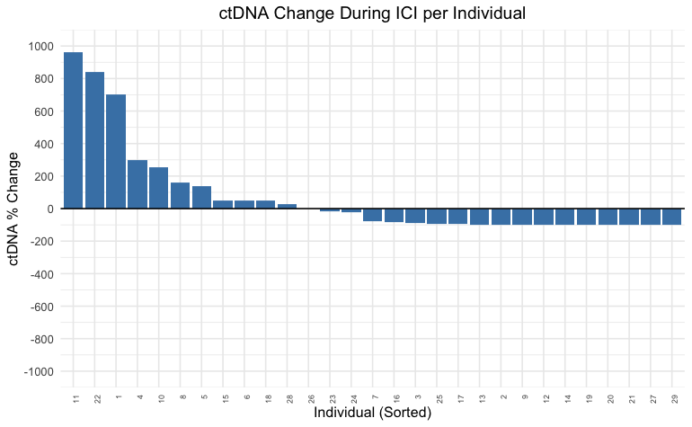

```r
rm(list = ls())
setwd("~/Downloads")
circ_data <- read.csv("EORTC HNSCC ICI Clinical Data.csv")
circ_data <- circ_data[circ_data$ctDNA.available == "TRUE", ]
circ_data <- circ_data[circ_data$ctDNA.Base!="",]
circ_data$ctDNA.change <- as.numeric(circ_data$ctDNA.change)
circ_data$SubjectID <- seq_len(nrow(circ_data))
circ_data <- circ_data %>% arrange(desc(ctDNA.change))
circ_data$SubjectID <- factor(circ_data$SubjectID, levels = circ_data$SubjectID)

ggplot(circ_data, aes(x = SubjectID, y = ctDNA.change)) +
  geom_bar(stat = "identity", fill = "steelblue") +
  geom_hline(yintercept = 0, color = "black") +
  scale_y_continuous(
    breaks = seq(-1000, 1000, by = 200),
    limits = c(-1000, 1000)
  ) +
  labs(
    x = "Individual (Sorted)",
    y = "ctDNA % Change",
    title = "ctDNA Change During ICI per Individual"
  ) +
  theme_minimal() +
  theme(
    axis.text.x = element_text(angle = 90, hjust = 1, size = 6),
    plot.title = element_text(hjust = 0.5)
  )
```

#Heatmap for the clinical factors and top 10 most common mutations

```r
rm(list=ls())
setwd("~/Downloads")
circ_data <- read.csv("EORTC HNSCC ICI Clinical Data.csv")
circ_data <- circ_data[circ_data$ctDNA.available=="TRUE",]
circ_data <- circ_data[circ_data$ctDNA.Base!="",]
circ_data$ctDNA.change <- as.numeric(circ_data$ctDNA.change)
circ_data <- circ_data %>% arrange(desc(ctDNA.change))
circ_datadf <- as.data.frame(circ_data)

ha <- HeatmapAnnotation(
  Inclusion.status = circ_data$Inclusion.status,
  Immunotherapy = circ_data$Immunotherapy,
  ECOG.v2 = circ_data$ECOG.v2,
  p16.status = circ_data$p16.status,
  TP53 = circ_data$TP53,
  CDKN2A = circ_data$CDKN2A,
  FAT1 = circ_data$FAT1,
  APOB = circ_data$APOB,
  LAMA1 = circ_data$LAMA1,
  NOTCH1 = circ_data$NOTCH1,
  PCDHB13 = circ_data$PCDHB13,
  DCHS1 = circ_data$DCHS1,
  FSIP2 = circ_data$FSIP2,
  LRP1B = circ_data$LRP1B,
  ctDNA.Base = circ_data$ctDNA.Base,
  ctDNA.postTx = circ_data$ctDNA.postTx,
  RESIST = circ_data$RESIST,
  PFS.Event = circ_data$PFS.Event,
  OS.Event = circ_data$OS.Event,

  col = list(Inclusion.status = c("Loco-regional" = "seagreen1", "Metastatic" = "khaki"),
             Immunotherapy = c("Pembrolizumab" = "purple", "Nivolumab" ="lightblue"),
             ECOG.v2 = c("0" = "goldenrod" , "1/2" = "blue4"),
             p16.status = c("Negative" = "yellow", "Positive" ="brown", "Unknown" ="grey"),
             TP53 = c("MUT" = "black", "WT" ="grey"),
             CDKN2A = c("MUT" = "black", "WT" ="grey"),
             FAT1 = c("MUT" = "black", "WT" ="grey"),
             APOB = c("MUT" = "black", "WT" ="grey"),
             LAMA1 = c("MUT" = "black", "WT" ="grey"),
             NOTCH1 = c("MUT" = "black", "WT" ="grey"),
             PCDHB13 = c("MUT" = "black", "WT" ="grey"),
             DCHS1 = c("MUT" = "black", "WT" ="grey"),
             FSIP2 = c("MUT" = "black", "WT" ="grey"),
             LRP1B = c("MUT" = "black", "WT" ="grey"),
             ctDNA.Base = c("POSITIVE" = "red3", "NEGATIVE" ="blue"),
             ctDNA.postTx = c("POSITIVE" = "red3", "NEGATIVE" ="blue"),
             RESIST = c("CR" = "lightblue", "PR" ="blue", "SD" = "orange", "PD" ="red"),
             PFS.Event = c("TRUE" = "red3", "FALSE" ="blue"),
             OS.Event = c("TRUE" = "black", "FALSE" ="grey")
  )
)
ht <- Heatmap(matrix(nrow = 0, ncol = length(circ_data$Inclusion.status)),show_row_names = FALSE,cluster_rows = F,cluster_columns = FALSE, top_annotation = ha)
pdf("heatmap.pdf",width = 7, height = 7)
draw(ht, annotation_legend_side = "bottom")
dev.off()
```

#Frequency of top 10 mutations in ctDNA clearance vs non-clearance

```r
rm(list=ls())
setwd("~/Downloads")
circ_data <- read.csv("EORTC HNSCC ICI Clinical Data.csv")
circ_data <- circ_data[circ_data$ctDNA.available=="TRUE",]
circ_data <- circ_data[circ_data$ctDNA.Base!="",]
circ_data <- circ_data[circ_data$ctDNA.Base=="POSITIVE",]
circ_datadf <- as.data.frame(circ_data)

circ_data$ctDNA.Dynamics <- NA
circ_data <- circ_data %>%
  mutate(ctDNA.Dynamics = case_when(
    ctDNA.Base == "POSITIVE" & ctDNA.postTx == "NEGATIVE" ~ 1,
    ctDNA.Base == "POSITIVE" & ctDNA.postTx == "POSITIVE" ~ 2
  ))
circ_data$ctDNA.Dynamics <- factor(circ_data$ctDNA.Dynamics, levels=c("1","2"), labels = c("Clearance", "No Clearance"))
circ_data$TP53 <- factor(circ_data$TP53, levels=c("WT","MUT"))
circ_data$CDKN2A <- factor(circ_data$CDKN2A, levels=c("WT","MUT"))
circ_data$FAT1 <- factor(circ_data$FAT1, levels=c("WT","MUT"))
circ_data$APOB <- factor(circ_data$APOB, levels=c("WT","MUT"))
circ_data$LAMA1 <- factor(circ_data$LAMA1, levels=c("WT","MUT"))
circ_data$NOTCH1 <- factor(circ_data$NOTCH1, levels=c("WT","MUT"))
circ_data$PCDHB13 <- factor(circ_data$CUBN, levels=c("WT","MUT"))
circ_data$DCHS1 <- factor(circ_data$DCHS1, levels=c("WT","MUT"))
circ_data$FSIP2 <- factor(circ_data$FSIP2, levels=c("WT","MUT"))
circ_data$LRP1B <- factor(circ_data$LRP1B, levels=c("WT","MUT"))

mutation_genes <- c("TP53", "CDKN2A", "FAT1", "APOB", "LAMA1", "NOTCH1", "PCDHB13", "DCHS1", "FSIP2", "LRP1B")
summary_table <- data.frame(
  Gene = character(),
  Clearance_MUT_Percent = numeric(),
  No_Clearance_MUT_Percent = numeric(),
  Overall_MUT_Percent = numeric(),
  Fisher_p_value = numeric(),
  stringsAsFactors = FALSE
)
for (gene in mutation_genes) {
  subset_data <- circ_data[!is.na(circ_data[[gene]]) & !is.na(circ_data$ctDNA.Dynamics), ]
  tab <- table(subset_data[[gene]], subset_data$ctDNA.Dynamics)
  total_clearance <- sum(tab[, "Clearance"])
  total_no_clearance <- sum(tab[, "No Clearance"])
  total_all <- sum(tab)
  pct_clearance <- if ("MUT" %in% rownames(tab)) 100 * tab["MUT", "Clearance"] / total_clearance else 0
  pct_no_clearance <- if ("MUT" %in% rownames(tab)) 100 * tab["MUT", "No Clearance"] / total_no_clearance else 0
  pct_overall <- if ("MUT" %in% rownames(tab)) 100 * sum(tab["MUT", ]) / total_all else 0
  fisher_p <- if (all(dim(tab) == c(2,2))) fisher.test(tab)$p.value else NA
  summary_table <- rbind(summary_table, data.frame(
    Gene = gene,
    Clearance_MUT_Percent = round(pct_clearance, 1),
    No_Clearance_MUT_Percent = round(pct_no_clearance, 1),
    Overall_MUT_Percent = round(pct_overall, 1),
    Fisher_p_value = signif(fisher_p, 3)
  ))
}
print(summary_table)
```

| Gene | Clearance_MUT_Percent | No_Clearance_MUT_Percent | Overall_MUT_Percent | Fisher_p_value |
| --- | --- | --- | --- | --- |
| TP53 | 83.3 | 73.7 | 76 | 1.000 |
| CDKN2A | 66.7 | 26.3 | 36 | 0.142 |
| FAT1 | 33.3 | 21.1 | 24 | 0.606 |
| APOB | 0.0 | 21.1 | 16 | 0.540 |
| LAMA1 | 16.7 | 15.8 | 16 | 1.000 |
| NOTCH1 | 33.3 | 10.5 | 16 | 0.234 |
| PCDHB13 | 16.7 | 15.8 | 16 | 1.000 |
| DCHS1 | 0.0 | 21.1 | 16 | 0.540 |
| FSIP2 | 16.7 | 15.8 | 16 | 1.000 |
| LRP1B | 16.7 | 15.8 | 16 | 1.000 |